Back to Article

###### EI_Hurst

Download Source

# EI_Hurst

Author

Lydia Sochan and Alex Weber

Published

February 15, 2025

Code Links

[GitHub Repo](https://github.com/WeberLab/EI_Hurst_Manuscript/),[Launch Binder](https://mybinder.org/v2/gh/WeberLab/EI_Hurst_Manuscript/HEAD?urlpath=rstudio)

```
In [1]:
```

```r
# First, let's load our packages.
library(FactoMineR)
library(Hmisc)
library(broom.mixed)
library(corrplot)
library(corrr)
library(factoextra)
library(formattable)
library(ggcorrplot)
library(ggrepel)
library(glmnet)
library(lme4)
library(lmerTest)
library(lsr)
library(nlme)
library(patchwork)
library(performance)
library(psych)
library(report)
library(reshape2)
library(rio)
library(tidyverse)
library(viridis)
library(simr)
library(car)
```

# Load and Format Data

```
In [2]:
```

```r
### LOAD DATA

# Base directory
base_dir <- "../Data/participant_measures/"

# Create filenames
filenames <- paste0(base_dir, "sub-Pilot", sprintf("%02d", 1:26), "_EI_Hurst_Measures.tsv")

# Function to read and process a single file
read_and_process <- function(filename) {
  # Read the file
  data <- import(filename, fill = T)

  # Extract the subject number from the filename
  subject_number <- gsub(".*sub-Pilot(\\d+).*", "\\1", filename)

  # Add the subject number column
  data <- mutate(data, Subject = subject_number)
  data <- data %>% select(Subject, everything())

  return(data)
}

# Apply the function to each file
list_of_dataframes <- lapply(filenames, read_and_process)

# Combine all dataframes into one and reformat some columns
df <- bind_rows(list_of_dataframes)
df$Subject <- as.numeric(df$Subject) # Change Subject column to numeric
num_subjects <- length(df$Subject) # Count the number of subjects
```

# Original subjects demographics

Load SubjectInfo.csv

```
In [3]:
```

```r
# Let's start by compiling our dataframe with subject demographics. We create a function to calculate age at scan from birthday and scan date.

# Subject Info
subjects <- read.csv("../Data/participant_measures/SubjectInfo.csv")
orig_subjects <- subjects
orig_subjects$Age <- as.numeric(interval(dmy(orig_subjects$DOB), dmy(orig_subjects$DOS)) / years(1))
#keep original df:
olddf <- df
```

Of the original 26 subjects we scanned:  
mean age = 29.7172825  
age range = 20.969863, 53.3961749  
number of males = 11

# Filter Data

Let’s remove any subject that have fMRI mean framewise displacement > 0.15mm, and anyone with a MRS water FWHM > 10:

```
In [4]:
```

```r
## only include selected participants
meanfdcutoff=0.15
FWHMcutoff=10
fmriremoved <- olddf %>% dplyr::filter(Rest_MeanFD > meanfdcutoff | Movie_MeanFD >meanfdcutoff)
mrsremoved <- olddf %>% dplyr::filter(Rest_laser_osprey_waterfwhm > FWHMcutoff | Rest_mega_osprey_waterfwhm > FWHMcutoff | Movie_mega_osprey_waterfwhm > FWHMcutoff | Movie_laser_osprey_waterfwhm > FWHMcutoff)
df <- df %>% dplyr::filter(Rest_MeanFD <= meanfdcutoff, Movie_MeanFD <= meanfdcutoff, Rest_laser_osprey_waterfwhm <= FWHMcutoff, Rest_mega_osprey_waterfwhm <= FWHMcutoff, Movie_mega_osprey_waterfwhm <= FWHMcutoff, Movie_laser_osprey_waterfwhm <= FWHMcutoff)
```

```
In [5]:
```

```r
write_csv(data.frame(df$Subject), "Subjects_for_analysis.csv")
```

# New Demographics

```
In [6]:
```

```r
subjects <- subjects[df$Subject, ]
num_subjects <- count(subjects)
year <- substring(subjects$DOB, 7, 10)
month <- substring(subjects$DOB, 4, 5)
day <- substring(subjects$DOB, 1, 2)
#subjects$DOB <- paste0(year, "-", month, "-", day)
subjects$Age <- as.numeric(interval(dmy(subjects$DOB), dmy(subjects$DOS)) / years(1))
subjects$Subject <- df$Subject
```

```
In [7]:
```

```r
count(orig_subjects) - count(subjects)
```

```
  n
1 8
```

Number of subjects lost: 8 After filtering, mean age = 29.5999434  
age range = 21.2896175, 53.3961749  
number of males = 8

```
In [8]:
```

```r
subs_clean <- dplyr::select(subjects, Subject, Age, Sex, Handedness)

color.picker.sex <- function(z) {
  if (z == "M") {
    return("lightblue")
  } else if (z == "F") {
    return("pink")
  } else {
    return("white")
  }
}
color.picker.hand <- function(z) {
  if (z == "L") {
    return("red")
  } else if (z == "R") {
    return("darkolivegreen1")
  } else {
    return("white")
  }
}

sub_dem <- formattable(subs_clean, list(
  Sex = formatter("span",
    style = x ~ style(
      display = "block",
      "border-radius" = "4px",
      "padding-right" = "4px",
      "background-color" = sapply(x, color.picker.sex)
    )
  ),
  Handedness = formatter("span",
    style = x ~ style(
      display = "block",
      "border-radius" = "4px",
      "padding-right" = "4px",
      "color" = sapply(x, color.picker.hand)
    )
  )
))
sub_dem
```

|  | Subject | Age | Sex | Handedness |
| --- | --- | --- | --- | --- |
| 1 | 1 | 24.90137 | F | R |
| 2 | 2 | 24.85205 | M | R |
| 4 | 4 | 27.90959 | F | R |
| 6 | 6 | 22.01366 | F | R |
| 7 | 7 | 21.70137 | F | R |
| 9 | 9 | 24.50411 | F | R |
| 10 | 10 | 27.61644 | F | R |
| 11 | 11 | 26.04098 | F | R |
| 12 | 12 | 31.34699 | F | R |
| 13 | 13 | 28.25683 | F | L |
| 15 | 15 | 53.39617 | M | R |
| 16 | 16 | 21.94247 | M | R |
| 18 | 18 | 21.28962 | M | R |
| 19 | 19 | 39.30874 | F | R |
| 20 | 20 | 37.74590 | M | R |
| 22 | 22 | 29.67213 | M | R |
| 24 | 24 | 43.59290 | M | R |
| 26 | 26 | 26.70765 | M | R |

Here are some summary statistics, grouped by sex, looking at age:

```
In [9]:
```

```r
sub_dem <- as.data.frame(sub_dem)
sub_dem <- na.omit(sub_dem)
sub_dem$Sex <- as.factor(sub_dem$Sex)
## exclude participants with insufficient MRS/fMRI quality metrics
print(paste0("Mean: ", mean(sub_dem$Age), " SD: ", sd(sub_dem$Age)))
```

```
[1] "Mean: 29.5999434422071 SD: 8.6554622907577"
```

```r
(sub_dem %>% group_by(Sex) %>% dplyr::summarize(n = length(Age), mean = round(mean(Age), 2), sd = round(sd(Age), 2), median = median(Age), IQR = IQR(Age), min = min(Age), max = max(Age)))
```

```
# A tibble: 2 × 8
  Sex       n  mean    sd median   IQR   min   max
  <fct> <int> <dbl> <dbl>  <dbl> <dbl> <dbl> <dbl>
1 F        10  27.4  5.12   26.8  3.57  21.7  39.3
2 M         8  32.4 11.5    28.2 15.1   21.3  53.4
```

```r
## Do males and females differ significantly by age?
sub_dem_f <- dplyr::filter(sub_dem, Sex == "F")
sub_dem_m <- dplyr::filter(sub_dem, Sex == "M")
mf_byage <- t.test(sub_dem_f$Age, sub_dem_m$Age)
print(mf_byage)
```

```
    Welch Two Sample t-test

data:  sub_dem_f$Age and sub_dem_m$Age
t = -1.1522, df = 9.2234, p-value = 0.2782
alternative hypothesis: true difference in means is not equal to 0
95 percent confidence interval:
 -14.898183   4.818478
sample estimates:
mean of x mean of y
 27.36001  32.39986
```

And a look at the distribution:

```
In [10]:
```

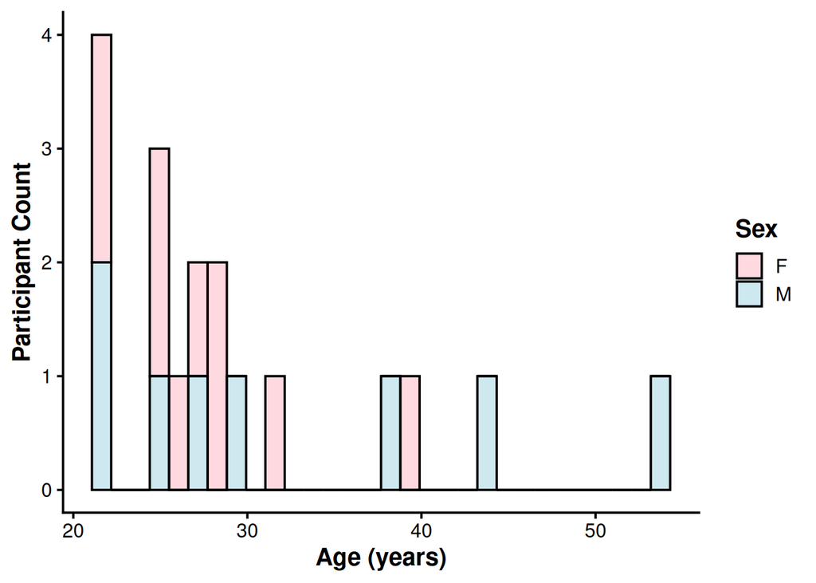

```r
(sub_dem_plot <- ggplot(sub_dem, aes(x = Age, group = Sex, fill = Sex)) +
  geom_histogram(position = "stack", alpha = 0.6, color = "black", boundary = 10) +
  theme_classic(base_size = 15) +
  scale_fill_manual(values = c("pink", "lightblue")) +
  theme(
    strip.background = element_blank(), strip.text.x = element_text(size = 15, face = "bold"),
    axis.title = element_text(face = "bold"), legend.title = element_text(face = "bold")
  ) +
  ylab("Participant Count") +
  xlab("Age (years)"))
```

```r
png(file = "Subject_Demographics_Plot.png", width = 7, height = 4, units = "in", res = 300)
sub_dem_plot
dev.off()
```

# Quality Assurance

## MRS

Before calculating our results, let’s look at the quality of our data. Let’s start with water full-width half-maximum, a quality measure for spectroscopy.

```
In [11]:
```

```r
## only include selected participants
fwhm_df <- dplyr::select(df, matches("FWHM")) %>% rename(Rest_FWHM_MEGAPRESS = Rest_mega_osprey_waterfwhm, Movie_FWHM_MEGAPRESS = Movie_mega_osprey_waterfwhm,
                                                         Rest_FWHM_SLASER = Rest_laser_osprey_waterfwhm, Movie_FWHM_SLASER = Movie_laser_osprey_waterfwhm) %>%
  reshape2::melt()
fwhm_df$Condition <- gsub("_.*", "", fwhm_df$variable)
fwhm_df$Method <- gsub(".*_.*_", "", fwhm_df$variable)
fwhm_df <- fwhm_df[, -1]
names(fwhm_df)[1] <- "FWHM"
fwhm_df$Condition <- factor(fwhm_df$Condition, levels = c("Rest", "Movie"))
mp_superFWHMcutoff <- nrow(fwhm_df %>% dplyr::filter(Method == "MEGAPRESS", FWHM > FWHMcutoff))
sl_superFWHMcutoff <- nrow(fwhm_df %>% dplyr::filter(Method == "SLASER", FWHM > FWHMcutoff))
fwhm_annot <- data.frame(c("MEGAPRESS", "SLASER"), c(paste0("n=", mp_superFWHMcutoff), paste0("n=", sl_superFWHMcutoff)))
names(fwhm_annot) <- c("Method", "Annotation")
```

Summary statistics:

```
In [12]:
```

```r
(fwhm_stats <- fwhm_df %>% group_by(Condition, Method) %>% summarise(mean = round(mean(FWHM), 2), sd = round(sd(FWHM), 2)))
```

```
# A tibble: 4 × 4
# Groups:   Condition [2]
  Condition Method     mean    sd
  <fct>     <chr>     <dbl> <dbl>
1 Rest      MEGAPRESS  7.86  0.8
2 Rest      SLASER     8.47  0.66
3 Movie     MEGAPRESS  7.95  0.82
4 Movie     SLASER     8.32  0.72
```

```
In [13]:
```

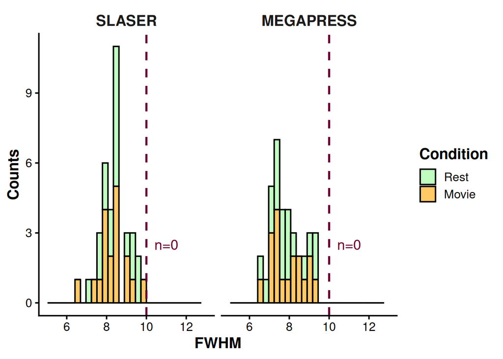

```r
(fwhm_plot <- ggplot(fwhm_df, aes(x = FWHM, group = Condition, fill = Condition)) +
  geom_histogram(position = "stack", alpha = 0.6, color = "black", boundary = 10) +
  facet_wrap(~ factor(Method, levels = c("SLASER", "MEGAPRESS"))) +
  theme_classic(base_size = 15) +
  scale_fill_manual(values = c("#98FB98", "#FFA500")) +
  theme(
    strip.background = element_blank(), strip.text.x = element_text(size = 15, face = "bold"),
    axis.title = element_text(face = "bold"), legend.title = element_text(face = "bold")
  ) +
  geom_vline(aes(xintercept = FWHMcutoff), linewidth = 1, color = "#660033", linetype = 2) +
  geom_text(data = fwhm_annot, mapping = aes(x = 11, y = 2.5, label = Annotation), color = "#660033", size = 5, inherit.aes = F) +
  ylab("Counts") +
  xlim(5, 13))
```

```r
png(file = "FWHM_Plot.png", width = 7, height = 4, units = "in", res = 300)
fwhm_plot
dev.off()
```

Who are the subjects, and under which condition, do we have FWHM > 10?

```
In [14]:
```

```r
fwhm_df <- dplyr::select(olddf, grep("fwhm", names(olddf)))
fwhm_df <- fwhm_df %>% rename(Rest_FWHM_MEGAPRESS = Rest_mega_osprey_waterfwhm, Movie_FWHM_MEGAPRESS = Movie_mega_osprey_waterfwhm, Rest_FWHM_SLASER = Rest_laser_osprey_waterfwhm, Movie_FWHM_SLASER = Movie_laser_osprey_waterfwhm)
head(fwhm_df)
```

```
  Rest_FWHM_SLASER Movie_FWHM_SLASER Rest_FWHM_MEGAPRESS Movie_FWHM_MEGAPRESS
1         8.363706          8.037434            7.382118             7.410975
2         8.568759          7.716863            7.731229             7.153868
3        11.376534         11.113369            9.637813             9.937978
4         8.612697          8.926322            9.225640             8.561476
5         8.062174          8.518361            8.507054             7.492048
6         8.006963          7.942560            7.354691             7.582831
```

```r
fwhm_df$SubjectID <- orig_subjects$SubjectID
fwhm_df <- reshape2::melt(fwhm_df)
fwhm_df$Condition <- gsub("_.*", "", fwhm_df$variable)
fwhm_df$Method <- gsub(".*_.*_", "", fwhm_df$variable)
fwhm_df <- fwhm_df %>% select(-c("variable"))
names(fwhm_df)[1] <- "Subject"
names(fwhm_df)[2] <- "FWHM"
fwhm_df$Condition <- factor(fwhm_df$Condition, levels = c("Rest", "Movie"))
(fwhm_df %>% filter(FWHM > FWHMcutoff))
```

```
  Subject     FWHM Condition Method
1 Pilot03 11.37653      Rest SLASER
2 Pilot17 10.39344      Rest SLASER
3 Pilot23 10.54568      Rest SLASER
4 Pilot03 11.11337     Movie SLASER
5 Pilot17 10.28991     Movie SLASER
```

### Cr_SNR

```
In [15]:
```

```r
crsnr_df <- dplyr::select(df, matches("crsnr")) %>% rename(Rest_CrSNR_MEGAPRESS = Rest_mega_osprey_crsnr, Movie_CrSNR_MEGAPRESS = Movie_mega_osprey_crsnr,
                                                         Rest_CrSNR_SLASER = Rest_laser_osprey_crsnr, Movie_CrSNR_SLASER = Movie_laser_osprey_crsnr) %>%
  reshape2::melt()
crsnr_df$Condition <- gsub("_.*", "", crsnr_df$variable)
crsnr_df$Method <- gsub(".*_.*_", "", crsnr_df$variable)
crsnr_df <- crsnr_df[, -1]
names(crsnr_df)[1] <- "cr_snr"
crsnr_df$Condition <- factor(crsnr_df$Condition, levels = c("Rest", "Movie"))
```

Summary statistics:

```
In [16]:
```

```r
(crsnr_stats <- crsnr_df %>% group_by(Condition, Method) %>% summarise(mean = round(mean(cr_snr), 2), sd = round(sd(cr_snr), 2)))
```

```
# A tibble: 4 × 4
# Groups:   Condition [2]
  Condition Method     mean    sd
  <fct>     <chr>     <dbl> <dbl>
1 Rest      MEGAPRESS 101.   21.4
2 Rest      SLASER    148.   20.5
3 Movie     MEGAPRESS  98.8  20.0
4 Movie     SLASER    141.   26
```

### Voxel Angle around X-axis:

```
In [17]:
```

```r
xangle_df <- dplyr::select(df, matches("Xangle"))
(xangle_stats <- xangle_df %>% summarise(mean = round(mean(Xangle), 2), sd = round(sd(Xangle), 2)))
```

```
  mean   sd
1  -39 8.13
```

### Tissue Fraction

```
In [18]:
```

```r
Tissue_fractions <- dplyr::select(df, c("GMfrac", "WMfrac", "CSFfrac")) %>%  reshape2::melt()
(Tissue_stats <- Tissue_fractions %>% group_by(variable)%>% summarise(mean = round(mean(value), 2), sd = round(sd(value), 2)))
```

```
# A tibble: 3 × 3
  variable  mean    sd
  <fct>    <dbl> <dbl>
1 GMfrac    0.64  0.04
2 WMfrac    0.24  0.04
3 CSFfrac   0.12  0.03
```

## Scanner Drift Sensitivity (Supplementary)

```
In [19]:
```

```r
drift_metrics <- df %>%
  select(
    Subject,
    Rest_FWHM_sLASER = Rest_laser_osprey_waterfwhm,
    Movie_FWHM_sLASER = Movie_laser_osprey_waterfwhm,
    Rest_FWHM_MEGA = Rest_mega_osprey_waterfwhm,
    Movie_FWHM_MEGA = Movie_mega_osprey_waterfwhm,
    Rest_SNR_sLASER = Rest_laser_osprey_crsnr,
    Movie_SNR_sLASER = Movie_laser_osprey_crsnr,
    Rest_SNR_MEGA = Rest_mega_osprey_crsnr,
    Movie_SNR_MEGA = Movie_mega_osprey_crsnr
  )

fwhm_long <- drift_metrics %>%
  select(Subject, starts_with("Rest_FWHM"), starts_with("Movie_FWHM")) %>%
  pivot_longer(
    cols = -Subject,
    names_to = c("Condition", "Sequence"),
    names_pattern = "(Rest|Movie)_FWHM_(.*)",
    values_to = "FWHM"
  )

snr_long <- drift_metrics %>%
  select(Subject, starts_with("Rest_SNR"), starts_with("Movie_SNR")) %>%
  pivot_longer(
    cols = -Subject,
    names_to = c("Condition", "Sequence"),
    names_pattern = "(Rest|Movie)_SNR_(.*)",
    values_to = "SNR"
  )

fwhm_summary <- fwhm_long %>%
  pivot_wider(names_from = Condition, values_from = FWHM) %>%
  mutate(Diff = Movie - Rest)

snr_summary <- snr_long %>%
  pivot_wider(names_from = Condition, values_from = SNR) %>%
  mutate(Diff = Movie - Rest)
```

```
In [20]:
```

```r
fwhm_tests <- fwhm_summary %>%
  group_by(Sequence) %>%
  summarise(
    mean_rest = mean(Rest),
    mean_movie = mean(Movie),
    mean_diff = mean(Diff),
    sd_diff = sd(Diff),
    test = list(t.test(Movie, Rest, paired = TRUE)),
    .groups = "drop"
  ) %>%
  mutate(
    t_value = map_dbl(test, ~ .x$statistic),
    p_value = map_dbl(test, ~ .x$p.value),
    conf_low = map_dbl(test, ~ .x$conf.int[1]),
    conf_high = map_dbl(test, ~ .x$conf.int[2])
  ) %>%
  select(-test)

snr_tests <- snr_summary %>%
  group_by(Sequence) %>%
  summarise(
    mean_rest = mean(Rest),
    mean_movie = mean(Movie),
    mean_diff = mean(Diff),
    sd_diff = sd(Diff),
    test = list(t.test(Movie, Rest, paired = TRUE)),
    .groups = "drop"
  ) %>%
  mutate(
    t_value = map_dbl(test, ~ .x$statistic),
    p_value = map_dbl(test, ~ .x$p.value),
    conf_low = map_dbl(test, ~ .x$conf.int[1]),
    conf_high = map_dbl(test, ~ .x$conf.int[2])
  ) %>%
  select(-test)

# Supplementary Table S2: linewidth and SNR stability metrics for reviewer R1.8
drift_table <- left_join(
  fwhm_summary %>% rename(Rest_FWHM = Rest, Movie_FWHM = Movie, Diff_FWHM = Diff),
  snr_summary %>% rename(Rest_SNR = Rest, Movie_SNR = Movie, Diff_SNR = Diff),
  by = c("Subject", "Sequence")
)
```

```
In [21]:
```

```r
knitr::kable(fwhm_tests, digits = 2, caption = "Supplementary Table S2a. Rest vs. movie FWHM comparison (paired t-tests) for each spectroscopy sequence.")
```

Supplementary Table S2a. Rest vs. movie FWHM comparison (paired t-tests) for each spectroscopy sequence.

| Sequence | mean_rest | mean_movie | mean_diff | sd_diff | t_value | p_value | conf_low | conf_high |
| --- | --- | --- | --- | --- | --- | --- | --- | --- |
| MEGA | 7.86 | 7.95 | 0.09 | 0.51 | 0.75 | 0.46 | -0.16 | 0.34 |
| sLASER | 8.47 | 8.32 | -0.15 | 0.49 | -1.28 | 0.22 | -0.39 | 0.10 |

```
In [22]:
```

```r
knitr::kable(snr_tests, digits = 2, caption = "Supplementary Table S2b. Rest vs. movie CR-SNR comparison (paired t-tests) for each spectroscopy sequence.")
```

Supplementary Table S2b. Rest vs. movie CR-SNR comparison (paired t-tests) for each spectroscopy sequence.

| Sequence | mean_rest | mean_movie | mean_diff | sd_diff | t_value | p_value | conf_low | conf_high |
| --- | --- | --- | --- | --- | --- | --- | --- | --- |
| MEGA | 101.05 | 98.75 | -2.30 | 9.39 | -1.04 | 0.31 | -6.97 | 2.36 |
| sLASER | 147.61 | 140.60 | -7.01 | 22.84 | -1.30 | 0.21 | -18.37 | 4.34 |

```
In [23]:
```

```r
knitr::kable(drift_table, digits = 2, caption = "Supplementary Table S2c. Subject-level FWHM and CR-SNR values for each sequence (Rest, Movie, and Movie–Rest difference).")
```

Supplementary Table S2c. Subject-level FWHM and CR-SNR values for each sequence (Rest, Movie, and Movie–Rest difference).

| Subject | Sequence | Rest_FWHM | Movie_FWHM | Diff_FWHM | Rest_SNR | Movie_SNR | Diff_SNR |
| --- | --- | --- | --- | --- | --- | --- | --- |
| 1 | sLASER | 8.36 | 8.04 | -0.33 | 135.58 | 125.26 | -10.32 |
| 1 | MEGA | 7.38 | 7.41 | 0.03 | 91.29 | 92.46 | 1.17 |
| 2 | sLASER | 8.57 | 7.72 | -0.85 | 128.76 | 147.92 | 19.16 |
| 2 | MEGA | 7.73 | 7.15 | -0.58 | 82.16 | 84.05 | 1.89 |
| 4 | sLASER | 8.61 | 8.93 | 0.31 | 162.00 | 132.33 | -29.67 |
| 4 | MEGA | 9.23 | 8.56 | -0.66 | 98.51 | 103.83 | 5.31 |
| 6 | sLASER | 8.01 | 7.94 | -0.06 | 130.77 | 152.24 | 21.47 |
| 6 | MEGA | 7.35 | 7.58 | 0.23 | 128.02 | 122.19 | -5.83 |
| 7 | sLASER | 9.08 | 9.10 | 0.02 | 112.42 | 99.45 | -12.97 |
| 7 | MEGA | 9.17 | 8.95 | -0.22 | 75.46 | 84.31 | 8.85 |
| 9 | sLASER | 8.27 | 8.53 | 0.26 | 172.88 | 161.56 | -11.32 |
| 9 | MEGA | 8.02 | 8.51 | 0.49 | 115.78 | 108.07 | -7.71 |
| 10 | sLASER | 7.65 | 7.46 | -0.20 | 168.43 | 173.85 | 5.41 |
| 10 | MEGA | 6.66 | 7.20 | 0.55 | 115.75 | 103.79 | -11.96 |
| 11 | sLASER | 9.53 | 8.57 | -0.96 | 157.59 | 136.11 | -21.48 |
| 11 | MEGA | 7.73 | 8.83 | 1.10 | 101.11 | 87.58 | -13.52 |
| 12 | sLASER | 8.39 | 7.79 | -0.60 | 180.44 | 136.71 | -43.73 |
| 12 | MEGA | 7.46 | 7.43 | -0.03 | 113.05 | 112.73 | -0.32 |
| 13 | sLASER | 7.73 | 8.45 | 0.72 | 158.00 | 207.77 | 49.78 |
| 13 | MEGA | 7.06 | 7.09 | 0.03 | 147.40 | 147.57 | 0.17 |
| 15 | sLASER | 9.27 | 8.25 | -1.03 | 161.54 | 135.97 | -25.57 |
| 15 | MEGA | 7.93 | 7.40 | -0.53 | 105.05 | 124.51 | 19.47 |
| 16 | sLASER | 9.23 | 9.19 | -0.04 | 155.48 | 135.41 | -20.07 |
| 16 | MEGA | 8.32 | 8.29 | -0.03 | 102.73 | 97.17 | -5.55 |
| 18 | sLASER | 8.57 | 8.33 | -0.24 | 116.65 | 117.28 | 0.62 |
| 18 | MEGA | 7.91 | 7.51 | -0.40 | 75.65 | 83.37 | 7.71 |
| 19 | sLASER | 8.39 | 8.57 | 0.18 | 169.98 | 145.07 | -24.92 |
| 19 | MEGA | 7.63 | 8.01 | 0.37 | 126.17 | 107.86 | -18.31 |
| 20 | sLASER | 7.94 | 7.93 | 0.00 | 146.29 | 156.69 | 10.40 |
| 20 | MEGA | 7.16 | 8.24 | 1.08 | 100.81 | 85.99 | -14.82 |
| 22 | sLASER | 9.51 | 9.86 | 0.35 | 121.74 | 96.63 | -25.11 |
| 22 | MEGA | 9.20 | 9.43 | 0.24 | 60.44 | 60.70 | 0.26 |
| 24 | sLASER | 7.18 | 6.67 | -0.50 | 138.38 | 121.95 | -16.43 |
| 24 | MEGA | 6.73 | 6.44 | -0.29 | 85.78 | 83.25 | -2.53 |
| 26 | sLASER | 8.12 | 8.42 | 0.31 | 140.13 | 148.61 | 8.48 |
| 26 | MEGA | 8.76 | 9.03 | 0.27 | 93.80 | 88.04 | -5.76 |

```
In [24]:
```

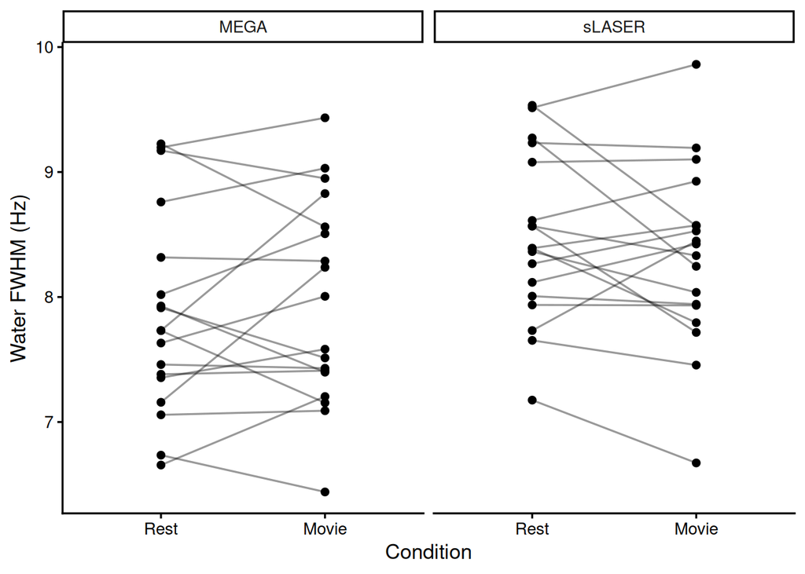

```r
(fwhm_drift_plot <- ggplot(fwhm_long, aes(x = Condition, y = FWHM, group = Subject)) +
  geom_line(alpha = 0.4) +
  geom_point(size = 1.8) +
  facet_wrap(~Sequence, nrow = 1) +
  scale_x_discrete(limits = c("Rest", "Movie")) +
  theme_classic(base_size = 13) +
  ylab("Water FWHM (Hz)") +
  xlab("Condition"))
```

```r
png(file = "FWHM_Drift_Plot.png", width = 7, height = 3, units = "in", res = 300)
fwhm_drift_plot
dev.off()
```

```
In [25]:
```

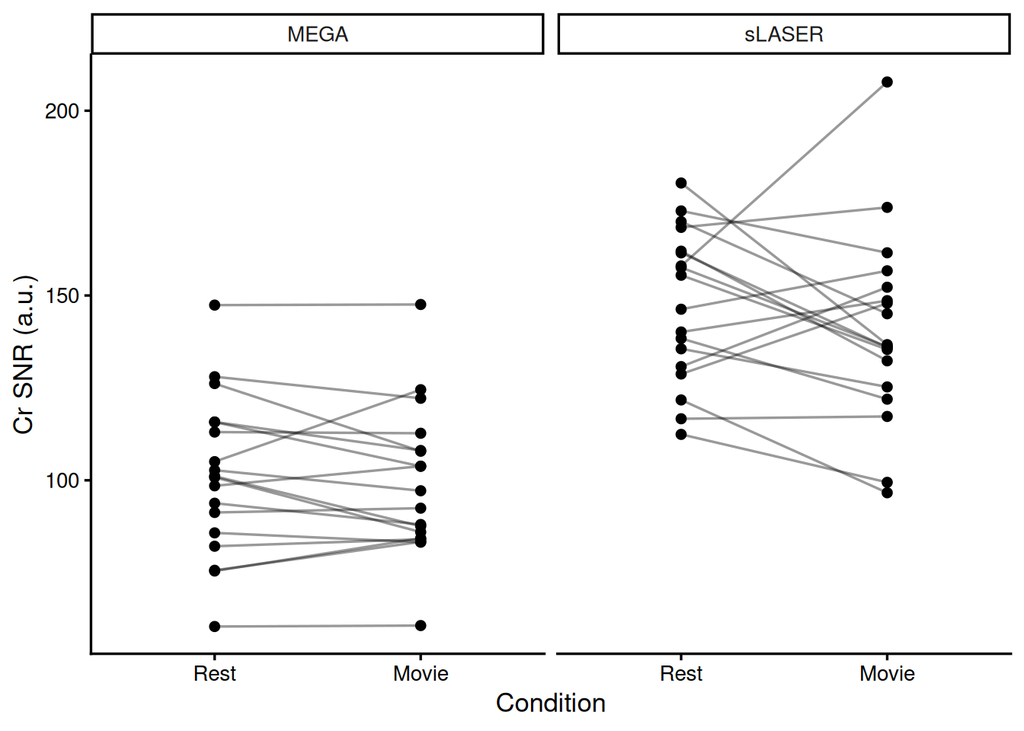

```r
(snr_drift_plot <- ggplot(snr_long, aes(x = Condition, y = SNR, group = Subject)) +
  geom_line(alpha = 0.4) +
  geom_point(size = 1.8) +
  facet_wrap(~Sequence, nrow = 1) +
  scale_x_discrete(limits = c("Rest", "Movie")) +
  theme_classic(base_size = 13) +
  ylab("Cr SNR (a.u.)") +
  xlab("Condition"))
```

```r
png(file = "SNR_Drift_Plot.png", width = 7, height = 3, units = "in", res = 300)
snr_drift_plot
dev.off()
```

## fMRI

Now let’s take a look at quality for our fMRI data. Mean framewise displacement (mean FD) is an estimate of a participant’s movement over time. In general, we want to see mean FD lower than 0.15.

Summary statistics:

```
In [26]:
```

```r
meanfd <- dplyr::select(df, Rest_MeanFD, Movie_MeanFD)
meanfd <- reshape2::melt(meanfd)
meanfd$Condition <- gsub("_.*", "", meanfd$variable)
meanfd <- meanfd[, -1]
meanfd$Condition <- factor(meanfd$Condition, levels = c("Rest", "Movie"))
names(meanfd)[1] <- "MeanFD"
meanfd_superp15 <- nrow(meanfd %>% dplyr::filter(MeanFD > meanfdcutoff))
meanfd_annot <- data.frame(c("MeanFD"), c(paste0("n=", meanfd_superp15)))
names(meanfd_annot) <- c("Measure", "Annotation")
```

```
In [27]:
```

```r
(fmri_stats <- meanfd %>% group_by(Condition) %>% summarise(mean = round(mean(MeanFD), 2), sd = round(sd(MeanFD), 2)))
```

```
# A tibble: 2 × 3
  Condition  mean    sd
  <fct>     <dbl> <dbl>
1 Rest        0.1  0.03
2 Movie       0.1  0.02
```

```
In [28]:
```

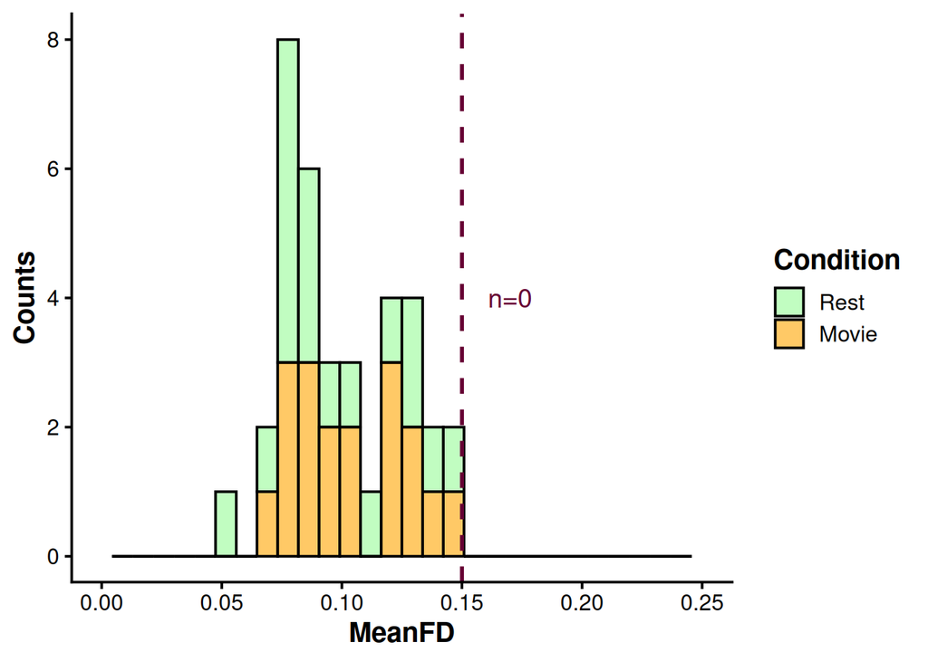

```r
(meanfd_plot <- ggplot(meanfd, aes(x = MeanFD, group = Condition, fill = Condition)) +
  geom_histogram(position = "stack", alpha = 0.6, color = "black", center = 10) +
  theme_classic(base_size = 15) +
  scale_fill_manual(values = c("#98FB98", "#FFA500")) +
  theme(axis.title = element_text(face = "bold"), legend.title = element_text(face = "bold")) +
  geom_vline(aes(xintercept = meanfdcutoff), linewidth = 1, color = "#660033", linetype = 2) +
  geom_text(data = meanfd_annot, mapping = aes(x = 0.17, y = 4, label = Annotation), color = "#660033", size = 5, inherit.aes = F) +
  ylab("Counts") +
  xlim(0, 0.25))
```

```r
png(file = "MeanFD_Plot.png", width = 7, height = 4, units = "in", res = 300)
meanfd_plot
dev.off()
```

Who are the subjects, and under what conditions, do we see meanFD > 0.15?

```
In [29]:
```

```r
meanfd2 <- dplyr::select(olddf, Rest_MeanFD, Movie_MeanFD)
meanfd2$SubjectID <- orig_subjects$SubjectID
meanfd2 <- reshape2::melt(meanfd2)
meanfd2$Condition <- gsub("_.*", "", meanfd2$variable)
meanfd2 <- meanfd2 %>% select(-c("variable"))
meanfd2$Condition <- factor(meanfd2$Condition, levels = c("Rest", "Movie"))
names(meanfd2)[1] <- "Subject"
names(meanfd2)[2] <- "meanFD"
(meanfd2 %>% filter(meanFD > meanfdcutoff))
```

```
  Subject    meanFD Condition
1 Pilot05 0.1689652      Rest
2 Pilot25 0.1517766      Rest
3 Pilot05 0.1987184     Movie
4 Pilot08 0.1529404     Movie
5 Pilot14 0.1531843     Movie
6 Pilot21 0.1729627     Movie
```

# Session Variability

Reviewer R1.7 noted that even within a single session, metabolite blocks acquired 10–15 minutes apart can be susceptible to adaptation or drift. We can directly address the within-session reliability concern by reporting the agreement between Glx derived from sLASER (Osprey) and MEGA-PRESS (Gannet).

```
In [30]:
```

```r
glx_agreement_long <- df %>%
  select(
    Subject,
    Rest_sLASER = Rest_laser_osprey_glx,
    Movie_sLASER = Movie_laser_osprey_glx,
    Rest_MEGA = Rest_mega_gannet_glx,
    Movie_MEGA = Movie_mega_gannet_glx
  ) %>%
  pivot_longer(
    cols = -Subject,
    names_to = c("Condition", "Sequence"),
    names_pattern = "(Rest|Movie)_(.*)",
    values_to = "Glx"
  ) %>%
  pivot_wider(names_from = Sequence, values_from = Glx) %>%
  drop_na(sLASER, MEGA)

glx_agreement_stats <- glx_agreement_long %>%
  mutate(Diff = sLASER - MEGA) %>%
  group_by(Condition) %>%
  summarise(
    n = n(),
    mean_sLASER = mean(sLASER),
    mean_MEGA = mean(MEGA),
    mean_difference = mean(Diff),
    sd_difference = sd(Diff),
    mean_abs_difference = mean(abs(Diff)),
    .groups = "drop"
  )

glx_cor_tests <- glx_agreement_long %>%
  group_by(Condition) %>%
  summarise(stats = list(cor.test(sLASER, MEGA, method = "pearson")), .groups = "drop") %>%
  mutate(
    pearson_r = map_dbl(stats, "estimate"),
    p_value = map_dbl(stats, "p.value"),
    conf_low = map_dbl(stats, ~ .$conf.int[1]),
    conf_high = map_dbl(stats, ~ .$conf.int[2])
  ) %>%
  select(-stats)

# Supplementary Table S1: Glx agreement metrics for reviewer R1.7
glx_agreement_table <- left_join(glx_agreement_stats, glx_cor_tests, by = "Condition")
glx_agreement_table
```

```
# A tibble: 2 × 11
  Condition     n mean_sLASER mean_MEGA mean_difference sd_difference
  <chr>     <int>       <dbl>     <dbl>           <dbl>         <dbl>
1 Movie        18       10.0       10.7          -0.673         0.900
2 Rest         18        9.84      10.8          -1.00          1.45
# ℹ 5 more variables: mean_abs_difference <dbl>, pearson_r <dbl>,
#   p_value <dbl>, conf_low <dbl>, conf_high <dbl>
```

```
In [31]:
```

```r
knitr::kable(glx_agreement_table, digits = 2, caption = "Supplementary Table S1. Agreement between sLASER- and MEGA-PRESS-derived Glx within each condition.")
```

Supplementary Table S1. Agreement between sLASER- and MEGA-PRESS-derived Glx within each condition.

| Condition | n | mean_sLASER | mean_MEGA | mean_difference | sd_difference | mean_abs_difference | pearson_r | p_value | conf_low | conf_high |
| --- | --- | --- | --- | --- | --- | --- | --- | --- | --- | --- |
| Movie | 18 | 10.04 | 10.72 | -0.67 | 0.90 | 0.91 | 0.25 | 0.31 | -0.24 | 0.64 |
| Rest | 18 | 9.84 | 10.84 | -1.00 | 1.45 | 1.28 | 0.06 | 0.80 | -0.42 | 0.51 |

```
In [32]:
```

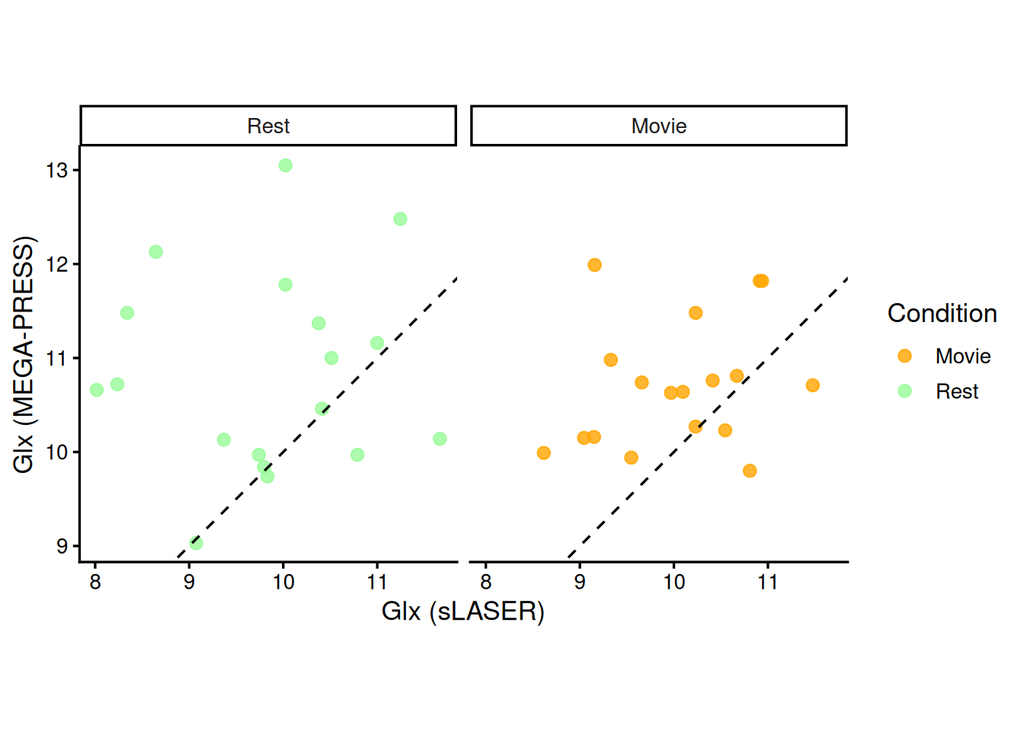

```r
(glx_agreement_plot <- ggplot(glx_agreement_long, aes(x = sLASER, y = MEGA, color = Condition)) +
  geom_point(alpha = 0.8, size = 2.5) +
  geom_abline(slope = 1, intercept = 0, linetype = 2) +
  facet_wrap(~factor(Condition, levels = c("Rest", "Movie"))) +
  theme_classic(base_size = 13) +
  scale_color_manual(values = c("Rest" = "#98FB98", "Movie" = "#FFA500")) +
  xlab("Glx (sLASER)") +
  ylab("Glx (MEGA-PRESS)") +
  coord_equal())
```

```r
png(file = "Glx_sLASER_vs_MEGA.png", width = 6, height = 3, units = "in", res = 300)
glx_agreement_plot
dev.off()
```

```
In [33]:
```

```r
library(dplyr)

# --- Load data ---
timingdf <- read.csv("Timing.csv", stringsAsFactors = FALSE)

# Trim whitespace from column names (in case of leading spaces)
names(timingdf) <- trimws(names(timingdf))

# --- Helper: parse HHMMSS integer to seconds since midnight ---
hhmmss_to_seconds <- function(x) {
  x <- as.integer(x)
  hh <- x %/% 10000
  mm <- (x %% 10000) %/% 100
  ss <- x %% 100
  hh * 3600 + mm * 60 + ss
}

# --- Convert all timing columns ---
timingdf <- timingdf %>%
  mutate(
    RestLaser_s  = hhmmss_to_seconds(RestLaser),
    RestMega_s   = hhmmss_to_seconds(RestMega),
    MovieLaser_s = hhmmss_to_seconds(MovieLaser),
    MovieMega_s  = hhmmss_to_seconds(MovieMega)
  )

# --- Compute per-subject differences (in seconds) ---
timingdf <- timingdf %>%
  mutate(
    Diff_Laser = abs(MovieLaser_s - RestLaser_s),
    Diff_Mega  = abs(MovieMega_s  - RestMega_s),
    Diff_Rest = abs(RestMega_s - RestLaser_s),
    Diff_Movie = abs(MovieMega_s - MovieLaser_s),
  )

# --- Print per-subject table ---
cat("=== Per-Subject Time Differences ===\n")
```

```
=== Per-Subject Time Differences ===
```

```r
print(timingdf %>% select(Subject, Diff_Laser, Diff_Mega, Diff_Rest, Diff_Movie))
```

```
   Subject Diff_Laser Diff_Mega Diff_Rest Diff_Movie
1        1       1712      1813       680        579
2        2       1630      1610       362        342
3        4       1664      1604       397        337
4        6       1592      1593       335        336
5        7       1065      2051       637        349
6        9       1614      1597       354        337
7       10       1601      1600       338        337
8       11       1608      1599       345        336
9       12       1635      1648       359        372
10      13       1601      1589       349        337
11      15       1780      1762       351        333
12      16       1714      1677       371        334
13      18       1609      1600       343        334
14      19       1620      1617       347        344
15      20       1598      1588       345        335
16      22       1612      1596       352        336
17      24       1929      1923       347        341
18      26       1637      1638       336        337
```

```r
# --- Compute and print averages ---
avg_laser <- mean(timingdf$Diff_Laser)
avg_mega  <- mean(timingdf$Diff_Mega)
sd_laser <- sd(timingdf$Diff_Laser)
sd_mega  <- sd(timingdf$Diff_Mega)
avg_rest <- mean(timingdf$Diff_Rest)
avg_movie  <- mean(timingdf$Diff_Movie)
sd_rest <- sd(timingdf$Diff_Rest)
sd_movie  <- sd(timingdf$Diff_Movie)

cat("\n=== average durations ===\n")
```

```
=== average durations ===
```

```r
cat(sprintf("average +/- sd time from restlaser  to movielaser : %.1f +/- %.1f seconds (%.2f +/- %.2f minutes)\n",
            avg_laser, sd_laser, avg_laser / 60, sd_laser / 60))
```

```
average +/- sd time from restlaser  to movielaser : 1623.4 +/- 162.9 seconds (27.06 +/- 2.71 minutes)
```

```r
cat(sprintf("average +/- sd time from restmega   to moviemega  : %.1f +/- %.1f seconds (%.2f +/- %.2f minutes)\n",
            avg_mega, sd_mega,  avg_mega  / 60, sd_mega / 60))
```

```
average +/- sd time from restmega   to moviemega  : 1672.5 +/- 131.8 seconds (27.88 +/- 2.20 minutes)
```

```r
cat(sprintf("average +/- sd time from restlaser  to restmega : %.1f +/- %.1f seconds (%.2f +/- %.2f minutes)\n",
            avg_rest, sd_rest, avg_rest / 60, sd_rest / 60))
```

```
average +/- sd time from restlaser  to restmega : 386.0 +/- 100.4 seconds (6.43 +/- 1.67 minutes)
```

```r
cat(sprintf("average +/- sd time from movielaser   to MovieMega  : %.1f +/- %.1f seconds (%.2f +/- %.2f minutes)\n",
            avg_movie, sd_movie,  avg_movie  / 60, sd_movie / 60))
```

```
average +/- sd time from movielaser   to MovieMega  : 353.1 +/- 57.1 seconds (5.89 +/- 0.95 minutes)
```

# Linear Mixed Effects (Welch Full Freq)

```
In [34]:
```

```r
df_lme <- df %>%
  select(Subject, Rest_Hurst, Movie_Hurst, Rest_laser_osprey_glx, Movie_laser_osprey_glx, Rest_mega_osprey_gabaplus, Movie_mega_osprey_gabaplus, Rest_laser_osprey_waterfwhm, Movie_laser_osprey_waterfwhm, Rest_mega_osprey_waterfwhm, Movie_mega_osprey_waterfwhm, Rest_MeanFD, Movie_MeanFD, Rest_laser_osprey_freqshift, Movie_laser_osprey_freqshift, Rest_mega_osprey_freqshift, Movie_mega_osprey_freqshift) %>%
  rename(Rest_Hurst = Rest_Hurst, Movie_Hurst = Movie_Hurst, Rest_FWHMsLASER = Rest_laser_osprey_waterfwhm, Movie_FWHMsLASER = Movie_laser_osprey_waterfwhm, Rest_FWHMMEGA = Rest_mega_osprey_waterfwhm, Movie_FWHMMEGA = Movie_mega_osprey_waterfwhm, Rest_Glx = Rest_laser_osprey_glx, Movie_Glx = Movie_laser_osprey_glx, Rest_GABAplus = Rest_mega_osprey_gabaplus, Movie_GABAplus = Movie_mega_osprey_gabaplus, Rest_FreqShiftsLASER = Rest_laser_osprey_freqshift, Movie_FreqShiftsLASER = Movie_laser_osprey_freqshift, Rest_FreqShiftMEGA = Rest_mega_osprey_freqshift, Movie_FreqShiftMEGA = Movie_mega_osprey_freqshift)
subjects_lme <- subjects %>% select(Age, Subject, Sex)
df_lme <- full_join(df_lme, subjects_lme, by = "Subject")
df_lme$Sex <- as.factor(df_lme$Sex)
```

```
In [35]:
```

```r
df_lme <- df_lme %>% pivot_longer(
  cols = -c(Age, Sex, Subject), # Exclude the Subject column from the transformation
  names_to = c("Condition", ".value"), # Split original column names
  names_pattern = "(.*)_(.*)" # Pattern to split the original column names
)
df_lme$EI <- df_lme$Glx / df_lme$GABAplus
df_lme$Condition <- as.factor(df_lme$Condition)
```

```
In [36]:
```

```r
model <- lme4::lmer(Hurst ~ EI + Condition + FWHMsLASER + FWHMMEGA + FreqShiftsLASER + FreqShiftMEGA + MeanFD + (1 | Subject), data = df_lme)
summary(model)
```

```
Linear mixed model fit by REML ['lmerMod']
Formula: Hurst ~ EI + Condition + FWHMsLASER + FWHMMEGA + FreqShiftsLASER +
    FreqShiftMEGA + MeanFD + (1 | Subject)
   Data: df_lme

REML criterion at convergence: -41.6

Scaled residuals:
     Min       1Q   Median       3Q      Max
-1.32019 -0.30559 -0.03204  0.30820  1.78867

Random effects:
 Groups   Name        Variance Std.Dev.
 Subject  (Intercept) 0.008682 0.09318
 Residual             0.003164 0.05625
Number of obs: 36, groups:  Subject, 18

Fixed effects:
                 Estimate Std. Error t value
(Intercept)      1.302336   0.329560   3.952
EI               0.068185   0.061087   1.116
ConditionRest   -0.066224   0.023306  -2.842
FWHMsLASER      -0.020659   0.035482  -0.582
FWHMMEGA         0.008205   0.029121   0.282
FreqShiftsLASER  0.034890   0.015124   2.307
FreqShiftMEGA    0.026900   0.017194   1.565
MeanFD          -0.591556   0.791977  -0.747

Correlation of Fixed Effects:
            (Intr) EI     CndtnR FWHMLA FWHMME FSLASE FSMEGA
EI          -0.245
ConditinRst -0.022  0.416
FWHMsLASER  -0.516 -0.201 -0.418
FWHMMEGA    -0.379  0.083  0.261 -0.465
FrqShfLASER  0.263  0.075 -0.067  0.082 -0.205
FrqShftMEGA  0.495  0.096  0.264 -0.383 -0.063  0.150
MeanFD      -0.160  0.145  0.334 -0.184  0.085 -0.187  0.318
```

```
In [37]:
```

```r
(vif_values <- car::vif(model))
```

```
             EI       Condition      FWHMsLASER        FWHMMEGA FreqShiftsLASER
       1.235038        1.545101        1.756968        1.448551        1.147912
  FreqShiftMEGA          MeanFD
       1.479268        1.276915
```

```
In [38]:
```

```r
model <- lmerTest::lmer(Hurst ~ EI + Condition + FWHMsLASER + FWHMMEGA + FreqShiftsLASER + FreqShiftMEGA + MeanFD + (1 | Subject), data = df_lme)
(model_summary <- summary(model))
```

```
Linear mixed model fit by REML. t-tests use Satterthwaite's method [
lmerModLmerTest]
Formula: Hurst ~ EI + Condition + FWHMsLASER + FWHMMEGA + FreqShiftsLASER +
    FreqShiftMEGA + MeanFD + (1 | Subject)
   Data: df_lme

REML criterion at convergence: -41.6

Scaled residuals:
     Min       1Q   Median       3Q      Max
-1.32019 -0.30559 -0.03204  0.30820  1.78867

Random effects:
 Groups   Name        Variance Std.Dev.
 Subject  (Intercept) 0.008682 0.09318
 Residual             0.003164 0.05625
Number of obs: 36, groups:  Subject, 18

Fixed effects:
                 Estimate Std. Error        df t value Pr(>|t|)
(Intercept)      1.302336   0.329560 27.403669   3.952 0.000493 ***
EI               0.068185   0.061087 16.998824   1.116 0.279870
ConditionRest   -0.066224   0.023306  9.849406  -2.842 0.017753 *
FWHMsLASER      -0.020659   0.035482 20.212422  -0.582 0.566842
FWHMMEGA         0.008205   0.029121 22.433612   0.282 0.780712
FreqShiftsLASER  0.034890   0.015124  8.710504   2.307 0.047388 *
FreqShiftMEGA    0.026900   0.017194 11.854688   1.565 0.143988
MeanFD          -0.591556   0.791977 26.759299  -0.747 0.461615
---
Signif. codes:  0 '***' 0.001 '**' 0.01 '*' 0.05 '.' 0.1 ' ' 1

Correlation of Fixed Effects:
            (Intr) EI     CndtnR FWHMLA FWHMME FSLASE FSMEGA
EI          -0.245
ConditinRst -0.022  0.416
FWHMsLASER  -0.516 -0.201 -0.418
FWHMMEGA    -0.379  0.083  0.261 -0.465
FrqShfLASER  0.263  0.075 -0.067  0.082 -0.205
FrqShftMEGA  0.495  0.096  0.264 -0.383 -0.063  0.150
MeanFD      -0.160  0.145  0.334 -0.184  0.085 -0.187  0.318
```

```
In [39]:
```

```r
(r2_values <- performance::r2(model))
```

```
# R2 for Mixed Models

  Conditional R2: 0.792
     Marginal R2: 0.220
```

```
In [40]:
```

```r
(confint_values <- lme4::confint.merMod(model, method="Wald"))
```

```
                       2.5 %      97.5 %
.sig01                    NA          NA
.sigma                    NA          NA
(Intercept)      0.656411574  1.94826143
EI              -0.051543480  0.18791310
ConditionRest   -0.111902727 -0.02054580
FWHMsLASER      -0.090202450  0.04888426
FWHMMEGA        -0.048871120  0.06528133
FreqShiftsLASER  0.005246909  0.06453220
FreqShiftMEGA   -0.006799307  0.06059838
MeanFD          -2.143801214  0.96069008
```

```
In [41]:
```

```r
report(model)
```

```
We fitted a linear mixed model (estimated using REML and nloptwrap optimizer)
to predict Hurst with EI, Condition, FWHMsLASER, FWHMMEGA, FreqShiftsLASER,
FreqShiftMEGA and MeanFD (formula: Hurst ~ EI + Condition + FWHMsLASER +
FWHMMEGA + FreqShiftsLASER + FreqShiftMEGA + MeanFD). The model included
Subject as random effect (formula: ~1 | Subject). The model's total explanatory
power is substantial (conditional R2 = 0.79) and the part related to the fixed
effects alone (marginal R2) is of 0.22. The model's intercept, corresponding to
EI = 0, Condition = Movie, FWHMsLASER = 0, FWHMMEGA = 0, FreqShiftsLASER = 0,
FreqShiftMEGA = 0 and MeanFD = 0, is at 1.30 (95% CI [0.62, 1.98], t(26) =
3.95, p < .001). Within this model:

  - The effect of EI is statistically non-significant and positive (beta = 0.07,
95% CI [-0.06, 0.19], t(26) = 1.12, p = 0.275; Std. beta = 0.15, 95% CI [-0.13,
0.43])
  - The effect of Condition [Rest] is statistically significant and negative
(beta = -0.07, 95% CI [-0.11, -0.02], t(26) = -2.84, p = 0.009; Std. beta =
-0.58, 95% CI [-1.00, -0.16])
  - The effect of FWHMsLASER is statistically non-significant and negative (beta
= -0.02, 95% CI [-0.09, 0.05], t(26) = -0.58, p = 0.565; Std. beta = -0.12, 95%
CI [-0.56, 0.31])
  - The effect of FWHMMEGA is statistically non-significant and positive (beta =
8.21e-03, 95% CI [-0.05, 0.07], t(26) = 0.28, p = 0.780; Std. beta = 0.06, 95%
CI [-0.36, 0.48])
  - The effect of FreqShiftsLASER is statistically significant and positive (beta
= 0.03, 95% CI [3.80e-03, 0.07], t(26) = 2.31, p = 0.029; Std. beta = 0.24, 95%
CI [0.03, 0.45])
  - The effect of FreqShiftMEGA is statistically non-significant and positive
(beta = 0.03, 95% CI [-8.44e-03, 0.06], t(26) = 1.56, p = 0.130; Std. beta =
0.23, 95% CI [-0.07, 0.54])
  - The effect of MeanFD is statistically non-significant and negative (beta =
-0.59, 95% CI [-2.22, 1.04], t(26) = -0.75, p = 0.462; Std. beta = -0.13, 95%
CI [-0.48, 0.23])

Standardized parameters were obtained by fitting the model on a standardized
version of the dataset. 95% Confidence Intervals (CIs) and p-values were
computed using a Wald t-distribution approximation.
```

Power analyses

```
In [42]:
```

```r
(power <- powerSim(model, fixed("EI", "z"), nsim=1000))
```

[output not shown]

```
boundary (singular) fit: see help('isSingular')
```

[output not shown]

```
boundary (singular) fit: see help('isSingular')
```

[output not shown]

```
Power for predictor 'EI', (95% confidence interval):
      25.70% (23.02, 28.53)

Test: z-test
      Effect size for EI is 0.068

Based on 1000 simulations, (0 warnings, 0 errors)
alpha = 0.05, nrow = 36

Time elapsed: 0 h 0 m 38 s

nb: result might be an observed power calculation
```

```
In [43]:
```

```r
modelpower <- summary(power)$mean
```

```
In [44]:
```

```r
model_modified <- model
fixef(model_modified)["EI"] <- 0.14
(power0.1 <- powerSim(model_modified, fixed("EI", "z"), nsim=1000))
```

[output not shown]

```
boundary (singular) fit: see help('isSingular')
```

[output not shown]

```
Power for predictor 'EI', (95% confidence interval):
      64.20% (61.14, 67.18)

Test: z-test
      Effect size for EI is 0.14

Based on 1000 simulations, (0 warnings, 0 errors)
alpha = 0.05, nrow = 36

Time elapsed: 0 h 0 m 38 s
```

```
In [45]:
```

```r
modelpower0.1 <- summary(power0.1)$mean
```

```
In [46]:
```

```r
model_modified <- model
fixef(model_modified)["EI"] <- 0.21
(power0.15 <- powerSim(model_modified, fixed("EI", "z"), nsim=1000))
```

[output not shown]

```
boundary (singular) fit: see help('isSingular')
```

[output not shown]

```
Power for predictor 'EI', (95% confidence interval):
      93.00% (91.24, 94.50)

Test: z-test
      Effect size for EI is 0.21

Based on 1000 simulations, (0 warnings, 0 errors)
alpha = 0.05, nrow = 36

Time elapsed: 0 h 0 m 38 s
```

```
In [47]:
```

```r
modelpower0.15 <- summary(power0.15)$mean
```

```
In [48]:
```

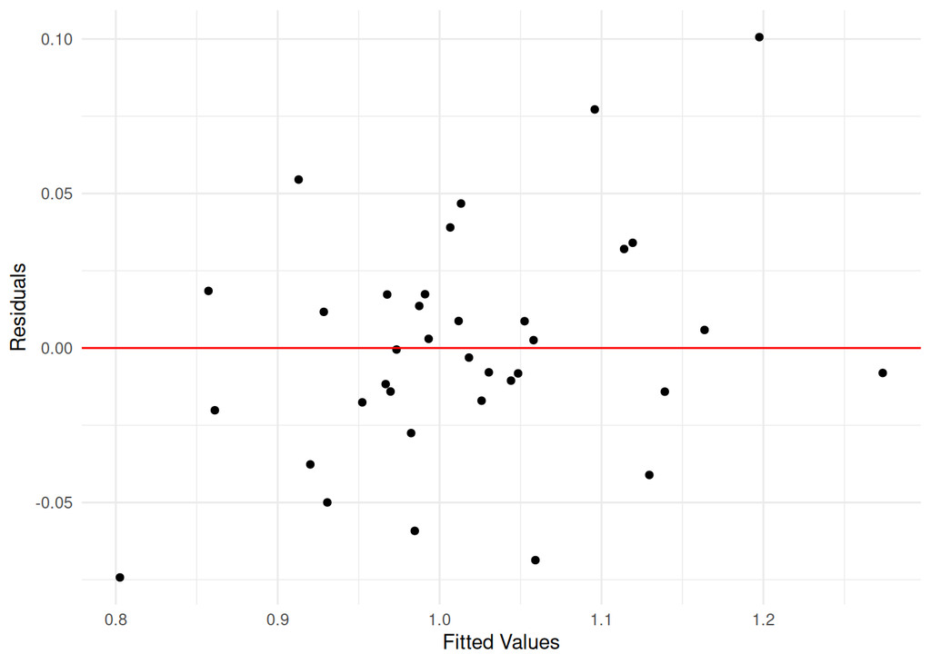

```r
(modelresiduals_plot <- ggplot(data.frame(fitted = fitted(model),
                       residuals = resid(model)),
            aes(x = fitted, y = residuals)) +
  geom_point() +
  geom_hline(yintercept = 0, color = "red") +
  labs(x = "Fitted Values", y = "Residuals") +
  theme_minimal())
```

```
In [49]:
```

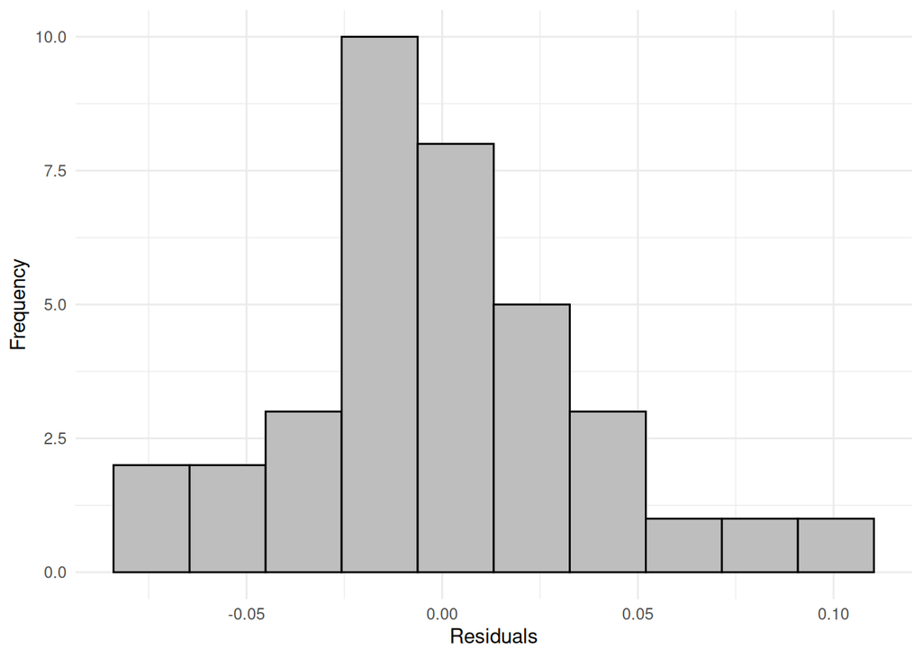

```r
# Create the plot as an object
(modelhistresiduals_plot <- ggplot(data.frame(residuals = resid(model)),
            aes(x = residuals)) +
  geom_histogram(bins = 10, fill = "grey", color = "black") +
  labs(x = "Residuals", y = "Frequency") +
  theme_minimal())
```

```
In [50]:
```

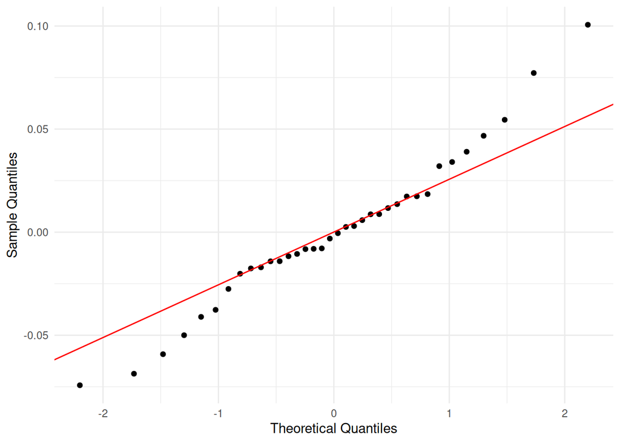

```r
(modelqqnorm_plot <- ggplot(data.frame(residuals = resid(model)),
                      aes(sample = residuals)) +
  stat_qq() +
  stat_qq_line(color = "red") +
  labs(x = "Theoretical Quantiles",
       y = "Sample Quantiles") +
  theme_minimal())
```

## Robustness Analyses

To address Reviewer R1.21’s request for sensitivity analyses, we report three complementary checks for the EI fixed effect.

```
In [51]:
```

```r
# Supplementary Table S3a: Spearman correlations between EI and Hurst for each condition (R1.21)
spearman_results <- df_lme %>%
  group_by(Condition) %>%
  summarise(
    spearman_ei_hurst = cor(EI, Hurst, method = "spearman"),
    p_value = cor.test(EI, Hurst, method = "spearman")$p.value,
    .groups = "drop"
  )
```

```
In [52]:
```

```r
knitr::kable(spearman_results, digits = 3, caption = "Supplementary Table S3a. Spearman correlation between EI and Hurst by condition.")
```

Supplementary Table S3a. Spearman correlation between EI and Hurst by condition.

| Condition | spearman_ei_hurst | p_value |
| --- | --- | --- |
| Movie | -0.300 | 0.225 |
| Rest | -0.125 | 0.621 |

```
In [53]:
```

```r
# Trimmed samples (remove top/bottom 10% for EI, Hurst, or both)
ei_bounds <- quantile(df_lme$EI, probs = c(0.1, 0.9), na.rm = TRUE)
hurst_bounds <- quantile(df_lme$Hurst, probs = c(0.1, 0.9), na.rm = TRUE)

df_trim_ei <- df_lme %>% filter(EI >= ei_bounds[1], EI <= ei_bounds[2])
df_trim_hurst <- df_lme %>% filter(Hurst >= hurst_bounds[1], Hurst <= hurst_bounds[2])
df_trim_both <- df_lme %>%
  filter(
    EI >= ei_bounds[1], EI <= ei_bounds[2],
    Hurst >= hurst_bounds[1], Hurst <= hurst_bounds[2]
  )

trim_model_ei <- lmerTest::lmer(Hurst ~ EI + Condition + FWHMsLASER + FWHMMEGA + FreqShiftsLASER + FreqShiftMEGA + MeanFD + (1 | Subject), data = df_trim_ei)
trim_model_hurst <- lmerTest::lmer(Hurst ~ EI + Condition + FWHMsLASER + FWHMMEGA + FreqShiftsLASER + FreqShiftMEGA + MeanFD + (1 | Subject), data = df_trim_hurst)
trim_model_both <- lmerTest::lmer(Hurst ~ EI + Condition + FWHMsLASER + FWHMMEGA + FreqShiftsLASER + FreqShiftMEGA + MeanFD + (1 | Subject), data = df_trim_both)

trim_models <- list(
  "Full sample" = model,
  "Trimmed EI (10–90%)" = trim_model_ei,
  "Trimmed Hurst (10–90%)" = trim_model_hurst,
  "Trimmed EI & Hurst (intersection)" = trim_model_both
)

robust_effects <- purrr::map_df(names(trim_models), function(nm) {
  m <- trim_models[[nm]]
  ci <- confint(m, parm = "EI", method = "Wald")
  tibble::tibble(
    Model = nm,
    Estimate = summary(m)$coefficients["EI", "Estimate"],
    SE = summary(m)$coefficients["EI", "Std. Error"],
    CI_low = ci[1],
    CI_high = ci[2]
  )
})
```

```
In [54]:
```

```r
knitr::kable(robust_effects, digits = 3, caption = "Supplementary Table S3b. EI fixed-effect estimates (Estimate ± 95% CI) for the full sample and each trimmed sample.")
```

Supplementary Table S3b. EI fixed-effect estimates (Estimate ± 95% CI) for the full sample and each trimmed sample.

| Model | Estimate | SE | CI_low | CI_high |
| --- | --- | --- | --- | --- |
| Full sample | 0.068 | 0.061 | -0.052 | 0.188 |
| Trimmed EI (10–90%) | 0.010 | 0.125 | -0.236 | 0.256 |
| Trimmed Hurst (10–90%) | 0.018 | 0.045 | -0.070 | 0.107 |
| Trimmed EI & Hurst (intersection) | 0.081 | 0.112 | -0.139 | 0.300 |

Taken together, the non-parametric Spearman correlations indicate that the EI–Hurst association is weak and not statistically detectable in this pilot dataset (Supplementary Table S3a). The trimmed mixed-effects analyses further show that the inference is not driven by extreme EI or H values: across trimming strategies, the EI fixed-effect remains small and its 95% confidence interval includes zero (Supplementary Table S3b). Trimming was performed on the pooled long-format dataset (combining rest and movie rows) to mirror the mixed-model specification, and Supplementary Table S3b provides the fixed-effect confidence intervals requested for the mixed-model sensitivity analysis.

# Post-hoc stats

```
In [55]:
```

```r
# Let's create a handy vector containing Hurst values and another containing glutamate values.
glx <- dplyr::select(df, Rest_laser_osprey_glx, Movie_laser_osprey_glx)
glx <- reshape2::melt(glx)
glx <- glx[, -1]
gabaplus <- dplyr::select(df, Rest_mega_osprey_gabaplus, Movie_mega_osprey_gabaplus)
gabaplus <- reshape2::melt(gabaplus)
gabaplus <- gabaplus[, -1]
hurst <- dplyr::select(df, Rest_Hurst, Movie_Hurst)
hurst <- reshape2::melt(hurst)
hurst <- hurst[, -1]
```

## Is meanFD correlated with Hurst?

```
In [56]:
```

```r
meanfd_rest <- dplyr::filter(meanfd, Condition == "Rest")
meanfd_movie <- dplyr::filter(meanfd, Condition == "Movie")
meanfd_rest.model <- cor.test(meanfd_rest$MeanFD, df$Rest_Hurst)
print(meanfd_rest.model)
```

```
    Pearson's product-moment correlation

data:  meanfd_rest$MeanFD and df$Rest_Hurst
t = -1.3864, df = 16, p-value = 0.1846
alternative hypothesis: true correlation is not equal to 0
95 percent confidence interval:
 -0.6890102  0.1645427
sample estimates:
       cor
-0.3274848
```

```r
meanfd_movie.model <- cor.test(meanfd_movie$MeanFD, df$Movie_Hurst)
print(meanfd_movie.model)
```

```
    Pearson's product-moment correlation

data:  meanfd_movie$MeanFD and df$Movie_Hurst
t = -2.2322, df = 16, p-value = 0.04025
alternative hypothesis: true correlation is not equal to 0
95 percent confidence interval:
 -0.7773265 -0.0264522
sample estimates:
       cor
-0.4873042
```

```r
t.test(meanfd_rest$MeanFD, meanfd_movie$MeanFD)
```

```
    Welch Two Sample t-test

data:  meanfd_rest$MeanFD and meanfd_movie$MeanFD
t = -0.7061, df = 33.721, p-value = 0.485
alternative hypothesis: true difference in means is not equal to 0
95 percent confidence interval:
 -0.02294745  0.01111583
sample estimates:
 mean of x  mean of y
0.09779846 0.10371427
```

```r
fd_hurst <- data.frame(meanfd$MeanFD, hurst)
names(fd_hurst) <- c("MeanFD", "Hurst")
fd_hurst_model <- lm(Hurst ~ MeanFD, data = fd_hurst)
(fd_hurst_model.summary <- summary(fd_hurst_model))
```

```
Call:
lm(formula = Hurst ~ MeanFD, data = fd_hurst)

Residuals:
     Min       1Q   Median       3Q      Max
-0.24151 -0.08839 -0.01111  0.08607  0.25303

Coefficients:
            Estimate Std. Error t value Pr(>|t|)
(Intercept)  1.17058    0.07687  15.228   <2e-16 ***
MeanFD      -1.53243    0.74115  -2.068   0.0464 *
---
Signif. codes:  0 '***' 0.001 '**' 0.01 '*' 0.05 '.' 0.1 ' ' 1

Residual standard error: 0.1094 on 34 degrees of freedom
Multiple R-squared:  0.1117,    Adjusted R-squared:  0.08557
F-statistic: 4.275 on 1 and 34 DF,  p-value: 0.04635
```

```
In [57]:
```

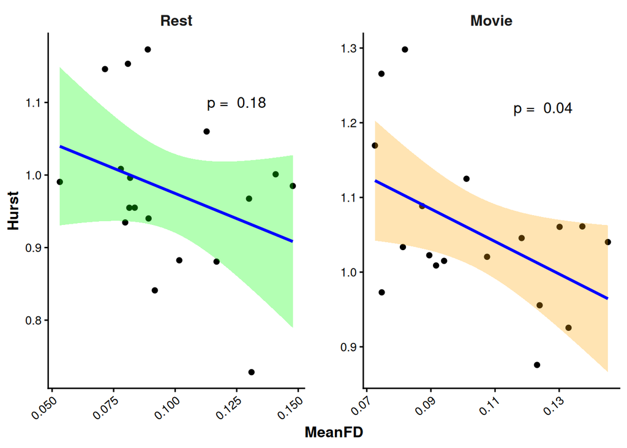

```r
# pearson_fd_hurst <- cor.test(fd_hurst$MeanFD, fd_hurst$Hurst, method="pearson")
meanfd$Hurst <- fd_hurst$Hurst

dat_text <- data.frame(
  label = c(paste("p = ", round(meanfd_rest.model$p.value, 2)), paste("p = ", round(meanfd_movie.model$p.value, 2))),
  Condition = c("Rest", "Movie"),
  x = c(0.125, 0.125),
  y = c(1.1, 1.22)
)
(meanfd_hurst_plot <- ggplot(data = meanfd, aes(x = MeanFD, y = Hurst, color = Condition, fill = Condition)) +
  geom_point(color = "black") +
  geom_smooth(method = "lm", color = "blue", aes(fill = Condition), alpha = 0.3) +
  theme_classic(base_size = 12) +
  theme(
    strip.background = element_blank(), strip.text.x = element_text(size = 12, face = "bold"),
    axis.title = element_text(face = "bold"), legend.title = element_text(face = "bold")
  ) +
  theme(legend.position = "none")+
  facet_wrap(~ factor(Condition, levels = c("Rest", "Movie")), scales="free") +
  geom_text(
    data = dat_text,
    mapping = aes(x = x, y = y, label = label),
    inherit.aes = FALSE
  ) +
  scale_x_continuous(guide = guide_axis(angle = 40)) +
  theme(panel.spacing = unit(2, "lines")) +
  #scale_color_manual(values = c("Rest" = "green", "Movie" = "orange")) #+
  scale_fill_manual(values = c("Rest" = "green", "Movie" = "orange"))
)
```

```r
png(file = "MeanFD_Hurst_Plot.png", width = 7, height = 3, units = "in", res = 300)
meanfd_hurst_plot
dev.off()
```

## Is Glx or GABAplus correlated with FWHM?

```
In [58]:
```

```r
(Restglxcortest <- cor.test(df$Rest_laser_osprey_glx, df$Rest_laser_osprey_waterfwhm))
```

```
    Pearson's product-moment correlation

data:  df$Rest_laser_osprey_glx and df$Rest_laser_osprey_waterfwhm
t = 0.067303, df = 16, p-value = 0.9472
alternative hypothesis: true correlation is not equal to 0
95 percent confidence interval:
 -0.4536096  0.4799239
sample estimates:
       cor
0.01682326
```

```r
(Movieglxcortest <- cor.test(df$Movie_laser_osprey_glx, df$Movie_laser_osprey_waterfwhm))
```

```
    Pearson's product-moment correlation

data:  df$Movie_laser_osprey_glx and df$Movie_laser_osprey_waterfwhm
t = 0.098575, df = 16, p-value = 0.9227
alternative hypothesis: true correlation is not equal to 0
95 percent confidence interval:
 -0.4473796  0.4859173
sample estimates:
       cor
0.02463624
```

```r
(Restgabapluscortest <- cor.test(df$Rest_mega_osprey_gabaplus, df$Rest_mega_osprey_waterfwhm))
```

```
    Pearson's product-moment correlation

data:  df$Rest_mega_osprey_gabaplus and df$Rest_mega_osprey_waterfwhm
t = -1.7022, df = 16, p-value = 0.1081
alternative hypothesis: true correlation is not equal to 0
95 percent confidence interval:
 -0.72576465  0.09213955
sample estimates:
      cor
-0.391575
```

```r
(Moviegabapluscortest <- cor.test(df$Movie_mega_osprey_gabaplus, df$Movie_mega_osprey_waterfwhm))
```

```
    Pearson's product-moment correlation

data:  df$Movie_mega_osprey_gabaplus and df$Movie_mega_osprey_waterfwhm
t = 0.54459, df = 16, p-value = 0.5935
alternative hypothesis: true correlation is not equal to 0
95 percent confidence interval:
 -0.3542799  0.5661181
sample estimates:
      cor
0.1349036
```

```
In [59]:
```

```r
glxfwhm <- dplyr::select(df, matches("laser_osprey_waterfwhm")) %>% reshape2::melt()
glxfwhm$Condition <- gsub("_.*", "", glxfwhm$variable)
glxfwhm$Method <- gsub(".*_.*_", "", glxfwhm$variable)
glxfwhm <- glxfwhm[, -c(1,4)]
names(glxfwhm)[1] <- "FWHM"
glxfwhm$Glx <- glx
glxfwhm <- glxfwhm %>% mutate(Condition = factor(Condition, levels = c("Rest", "Movie")))
```

```
In [60]:
```

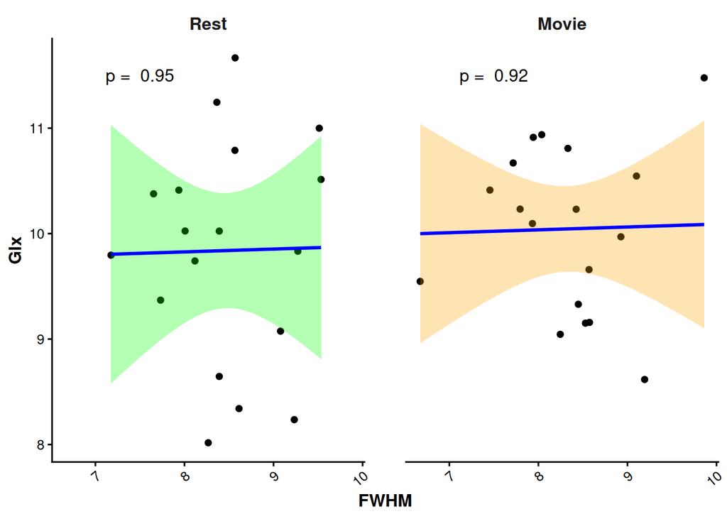

```r
dat_text <- data.frame(
  label = c(paste("p = ", round(Restglxcortest$p.value, 2)), paste("p = ", round(Movieglxcortest$p.value, 2))),
  Condition = c("Rest", "Movie"),
  x = c(7.5, 7.5),
  y = c(11.5, 11.5)
)
(glx_FWHM_plot <- ggplot(data = glxfwhm, aes(x = FWHM, y = Glx, color = Condition, fill = Condition)) +
  geom_point(color = "black") +
  geom_smooth(method = "lm", color = "blue", aes(fill = Condition), alpha = 0.3) +
  theme_classic(base_size = 12) +
  theme(
    strip.background = element_blank(), strip.text.x = element_text(size = 12, face = "bold"),
    axis.title = element_text(face = "bold"), legend.title = element_text(face = "bold")
  ) +
  theme(legend.position = "none") +
  facet_wrap(~ factor(Condition, levels = c("Rest", "Movie"))) +
  geom_text(
    data = dat_text,
    mapping = aes(x = x, y = y, label = label),
    inherit.aes = FALSE
  ) +
  ylab("Glx") +
  scale_x_continuous(guide = guide_axis(angle = 40)) +
  theme(panel.spacing = unit(2, "lines")) +
  #scale_color_manual(values = c("Rest" = "green", "Movie" = "orange")) #+
  scale_fill_manual(values = c("Rest" = "green", "Movie" = "orange"))
)
```

```r
png(file = "Glx_FWHM_Plot.png", width = 7, height = 3, units = "in", res = 300)
glx_FWHM_plot
dev.off()
```

```
In [61]:
```

```r
gabaplusfwhm <- dplyr::select(df, matches("mega_osprey_waterfwhm")) %>% reshape2::melt()
gabaplusfwhm$Condition <- gsub("_.*", "", gabaplusfwhm$variable)
gabaplusfwhm$Method <- gsub(".*_.*_", "", gabaplusfwhm$variable)
gabaplusfwhm <- gabaplusfwhm[, -c(1,4)]
names(gabaplusfwhm)[1] <- "FWHM"
gabaplusfwhm$gabaplus <- gabaplus
gabaplusfwhm <- gabaplusfwhm %>% mutate(Condition = factor(Condition, levels = c("Rest", "Movie")))
```

```
In [62]:
```

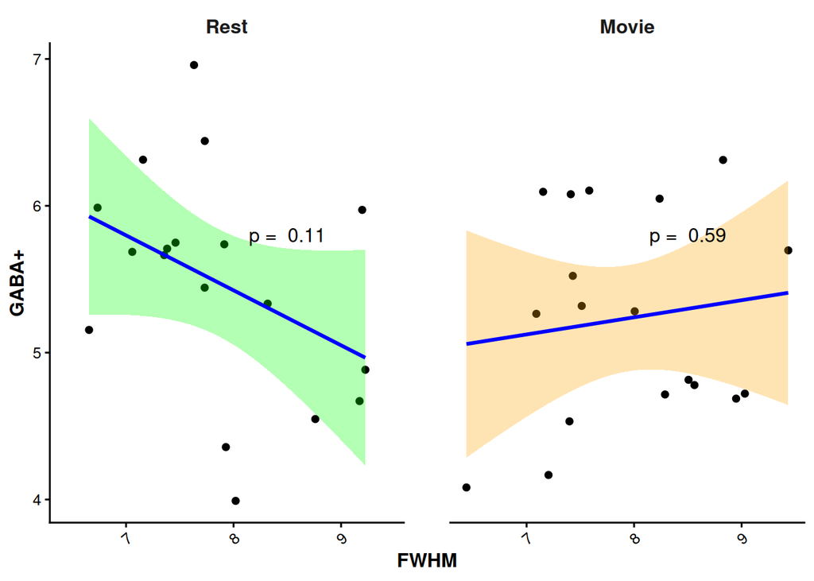

```r
dat_text <- data.frame(
  label = c(paste("p = ", round(Restgabapluscortest$p.value, 2)), paste("p = ", round(Moviegabapluscortest$p.value, 2))),
  Condition = c("Rest", "Movie"),
  x = c(8.5, 8.5),
  y = c(5.8, 5.8)
)
(gabaplus_FWHM_plot <- ggplot(data = gabaplusfwhm, aes(x = FWHM, y = gabaplus, color = Condition, fill = Condition)) +
  geom_point(color = "black") +
  geom_smooth(method = "lm", color = "blue", aes(fill = Condition), alpha = 0.3) +
  theme_classic(base_size = 12) +
  theme(
    strip.background = element_blank(), strip.text.x = element_text(size = 12, face = "bold"),
    axis.title = element_text(face = "bold"), legend.title = element_text(face = "bold")
  ) +
  theme(legend.position = "none") +
  facet_wrap(~ factor(Condition, levels = c("Rest", "Movie"))) +
  geom_text(
    data = dat_text,
    mapping = aes(x = x, y = y, label = label),
    inherit.aes = FALSE
  ) +
  ylab("GABA+") +
  scale_x_continuous(guide = guide_axis(angle = 40)) +
  theme(panel.spacing = unit(2, "lines")) +
  scale_fill_manual(values = c("Rest" = "green", "Movie" = "orange"))
)
```

```r
png(file = "GABAplus_FWHM_Plot.png", width = 7, height = 3, units = "in", res = 300)
gabaplus_FWHM_plot
dev.off()
```

```
In [63]:
```

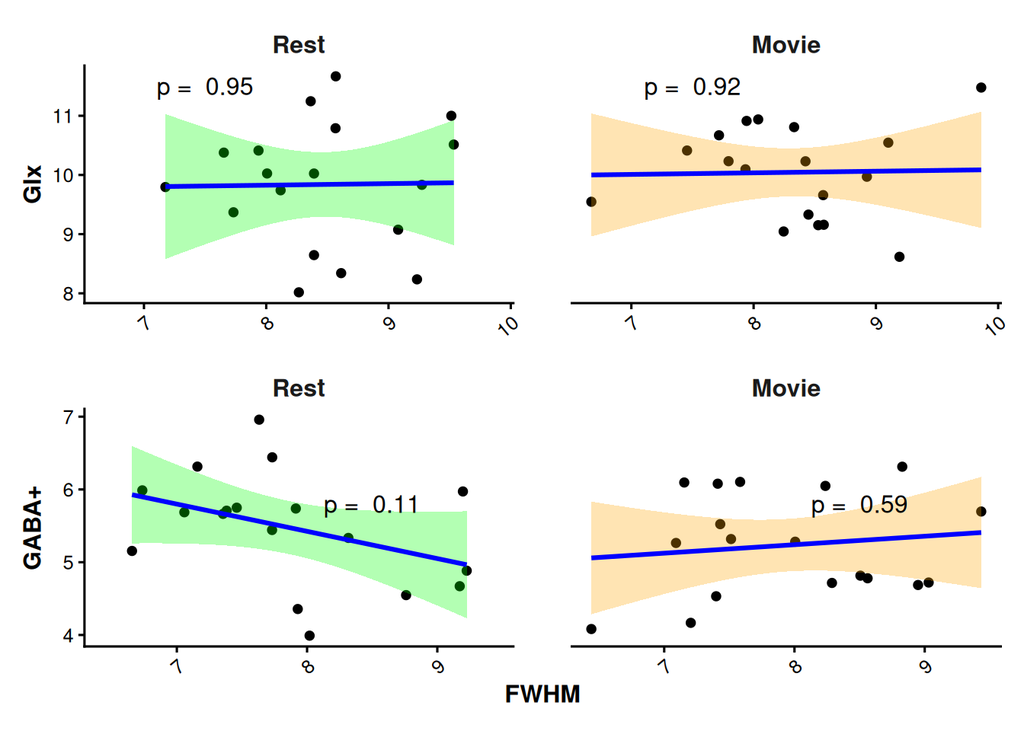

```r
(glxandgabaplus_FWHM_plot <- glx_FWHM_plot / gabaplus_FWHM_plot + plot_layout(guides = 'auto', axes = 'collect', axis_titles = 'collect'))
```

Are FWHM different between MEGAPRESS and sLASER?

```
In [64]:
```

```r
t.test(df$Rest_laser_osprey_waterfwhm, df$Rest_mega_osprey_waterfwhm)
```

```
    Welch Two Sample t-test

data:  df$Rest_laser_osprey_waterfwhm and df$Rest_mega_osprey_waterfwhm
t = 2.4854, df = 32.771, p-value = 0.01822
alternative hypothesis: true difference in means is not equal to 0
95 percent confidence interval:
 0.1105438 1.1096754
sample estimates:
mean of x mean of y
 8.467448  7.857338
```

```r
t.test(df$Movie_laser_osprey_waterfwhm, df$Movie_mega_osprey_waterfwhm)
```

```
    Welch Two Sample t-test

data:  df$Movie_laser_osprey_waterfwhm and df$Movie_mega_osprey_waterfwhm
t = 1.4465, df = 33.435, p-value = 0.1573
alternative hypothesis: true difference in means is not equal to 0
95 percent confidence interval:
 -0.1508480  0.8943228
sample estimates:
mean of x mean of y
 8.319767  7.948029
```

## FreqShift

```
In [65]:
```

```r
(Restglxfreqshiftcortest <- cor.test(df$Rest_laser_osprey_glx, df$Rest_laser_osprey_freqshift))
```

```
    Pearson's product-moment correlation

data:  df$Rest_laser_osprey_glx and df$Rest_laser_osprey_freqshift
t = 0.23995, df = 16, p-value = 0.8134
alternative hypothesis: true correlation is not equal to 0
95 percent confidence interval:
 -0.4186958  0.5124241
sample estimates:
       cor
0.05987921
```

```r
(Movieglxfreqshiftcortest <- cor.test(df$Movie_laser_osprey_glx, df$Movie_laser_osprey_freqshift))
```

```
    Pearson's product-moment correlation

data:  df$Movie_laser_osprey_glx and df$Movie_laser_osprey_freqshift
t = -1.8937, df = 16, p-value = 0.07649
alternative hypothesis: true correlation is not equal to 0
95 percent confidence interval:
 -0.74578074  0.04870248
sample estimates:
      cor
-0.427897
```

```r
(Restgabaplusfreqshiftcortest <- cor.test(df$Rest_mega_osprey_gabaplus, df$Rest_mega_osprey_freqshift))
```

```
    Pearson's product-moment correlation

data:  df$Rest_mega_osprey_gabaplus and df$Rest_mega_osprey_freqshift
t = -0.25011, df = 16, p-value = 0.8057
alternative hypothesis: true correlation is not equal to 0
95 percent confidence interval:
 -0.5142916  0.4166023
sample estimates:
        cor
-0.06240557
```

```r
(Moviegabaplusfreqshiftcortest <- cor.test(df$Movie_mega_osprey_gabaplus, df$Movie_mega_osprey_freqshift))
```

```
    Pearson's product-moment correlation

data:  df$Movie_mega_osprey_gabaplus and df$Movie_mega_osprey_freqshift
t = 0.27351, df = 16, p-value = 0.788
alternative hypothesis: true correlation is not equal to 0
95 percent confidence interval:
 -0.4117661  0.5185724
sample estimates:
       cor
0.06821841
```

```
In [66]:
```

```r
glxfreqshift <- dplyr::select(df, matches("laser_osprey_freqshift")) %>% reshape2::melt()
glxfreqshift$Condition <- gsub("_.*", "", glxfreqshift$variable)
glxfreqshift$Method <- gsub(".*_.*_", "", glxfreqshift$variable)
glxfreqshift <- glxfreqshift[, -c(1,4)]
names(glxfreqshift)[1] <- "freqshift"
glxfreqshift$Glx <- glx
glxfreqshift <- glxfreqshift %>% mutate(Condition = factor(Condition, levels = c("Rest", "Movie")))
```

```
In [67]:
```

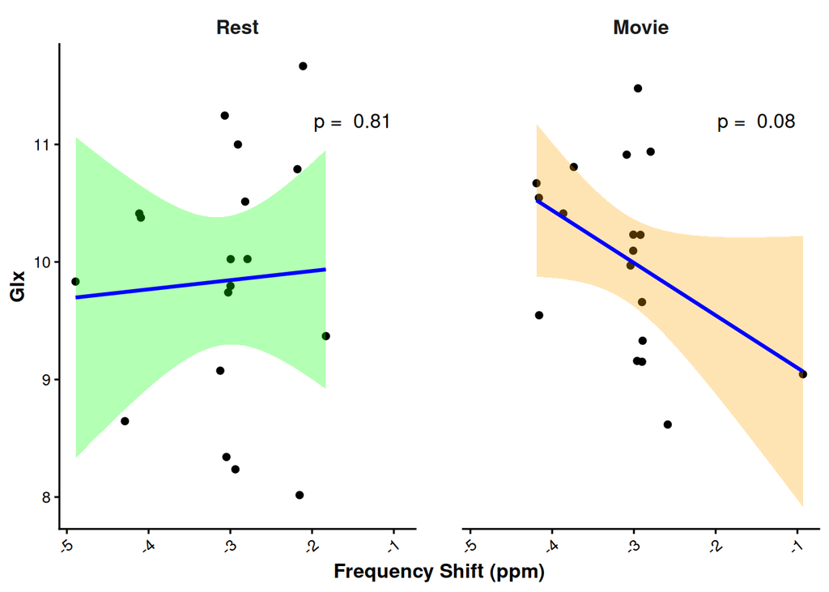

```r
dat_text <- data.frame(
  label = c(paste("p = ", round(Restglxfreqshiftcortest$p.value, 2)), paste("p = ", round(Movieglxfreqshiftcortest$p.value, 2))),
  Condition = c("Rest", "Movie"),
  x = c(-1.5, -1.5),
  y = c(11.2, 11.2)
)
(glx_freqshift_plot <- ggplot(data = glxfreqshift, aes(x = freqshift, y = Glx, color = Condition, fill = Condition)) +
  geom_point(color = "black") +
  geom_smooth(method = "lm", color = "blue", aes(fill = Condition), alpha = 0.3) +
  theme_classic(base_size = 12) +
  theme(
    strip.background = element_blank(), strip.text.x = element_text(size = 12, face = "bold"),
    axis.title = element_text(face = "bold"), legend.title = element_text(face = "bold")
  ) +
  theme(legend.position = "none") +
  facet_wrap(~ factor(Condition, levels = c("Rest", "Movie"))) +
  geom_text(
    data = dat_text,
    mapping = aes(x = x, y = y, label = label),
    inherit.aes = FALSE
  ) +
  ylab("Glx") +
  xlab("Frequency Shift (ppm)") +
  scale_x_continuous(guide = guide_axis(angle = 40)) +
  theme(panel.spacing = unit(2, "lines")) +
  #scale_color_manual(values = c("Rest" = "green", "Movie" = "orange")) #+
  scale_fill_manual(values = c("Rest" = "green", "Movie" = "orange"))
)
```

```r
png(file = "Glx_FreqShift_Plot.png", width = 7, height = 3, units = "in", res = 300)
glx_freqshift_plot
dev.off()
```

```
In [68]:
```

```r
gabaplusfreqshift <- dplyr::select(df, matches("mega_osprey_freqshift")) %>% reshape2::melt()
gabaplusfreqshift$Condition <- gsub("_.*", "", gabaplusfreqshift$variable)
gabaplusfreqshift$Method <- gsub(".*_.*_", "", gabaplusfreqshift$variable)
gabaplusfreqshift <- gabaplusfreqshift[, -c(1,4)]
names(gabaplusfreqshift)[1] <- "freqshift"
gabaplusfreqshift$gabaplus <- gabaplus
gabaplusfreqshift <- gabaplusfreqshift %>% mutate(Condition = factor(Condition, levels = c("Rest", "Movie")))
```

```
In [69]:
```

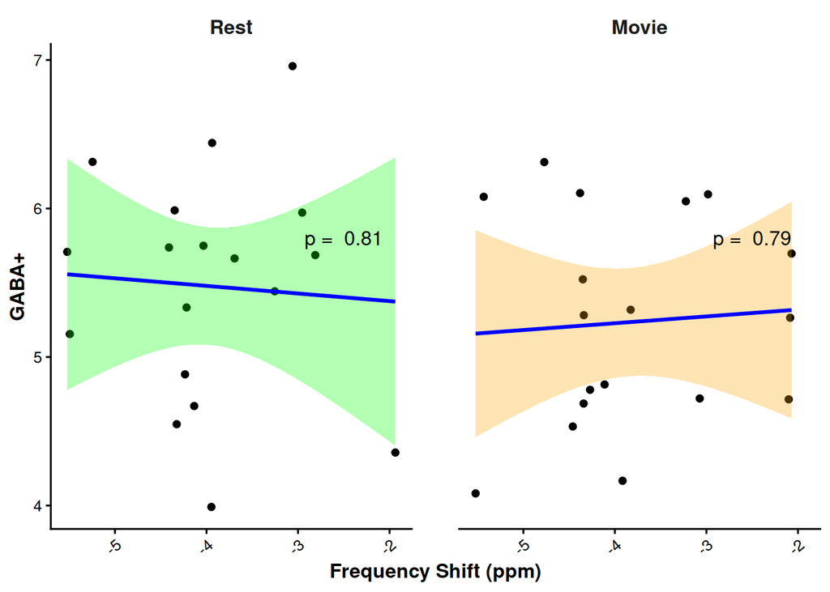

```r
dat_text <- data.frame(
  label = c(paste("p = ", round(Restgabaplusfreqshiftcortest$p.value, 2)), paste("p = ", round(Moviegabaplusfreqshiftcortest$p.value, 2))),
  Condition = c("Rest", "Movie"),
  x = c(-2.5, -2.5),
  y = c(5.8, 5.8)
)
(gabaplus_freqshift_plot <- ggplot(data = gabaplusfreqshift, aes(x = freqshift, y = gabaplus, color = Condition, fill = Condition)) +
  geom_point(color = "black") +
  geom_smooth(method = "lm", color = "blue", aes(fill = Condition), alpha = 0.3) +
  theme_classic(base_size = 12) +
  theme(
    strip.background = element_blank(), strip.text.x = element_text(size = 12, face = "bold"),
    axis.title = element_text(face = "bold"), legend.title = element_text(face = "bold")
  ) +
  theme(legend.position = "none") +
  facet_wrap(~ factor(Condition, levels = c("Rest", "Movie"))) +
  geom_text(
    data = dat_text,
    mapping = aes(x = x, y = y, label = label),
    inherit.aes = FALSE
  ) +
  ylab("GABA+") +
  xlab("Frequency Shift (ppm)") +
  scale_x_continuous(guide = guide_axis(angle = 40)) +
  theme(panel.spacing = unit(2, "lines")) +
  scale_fill_manual(values = c("Rest" = "green", "Movie" = "orange"))
)
```

```r
png(file = "GABAplus_freqshift_Plot.png", width = 7, height = 3, units = "in", res = 300)
gabaplus_freqshift_plot
dev.off()
```

```
In [70]:
```

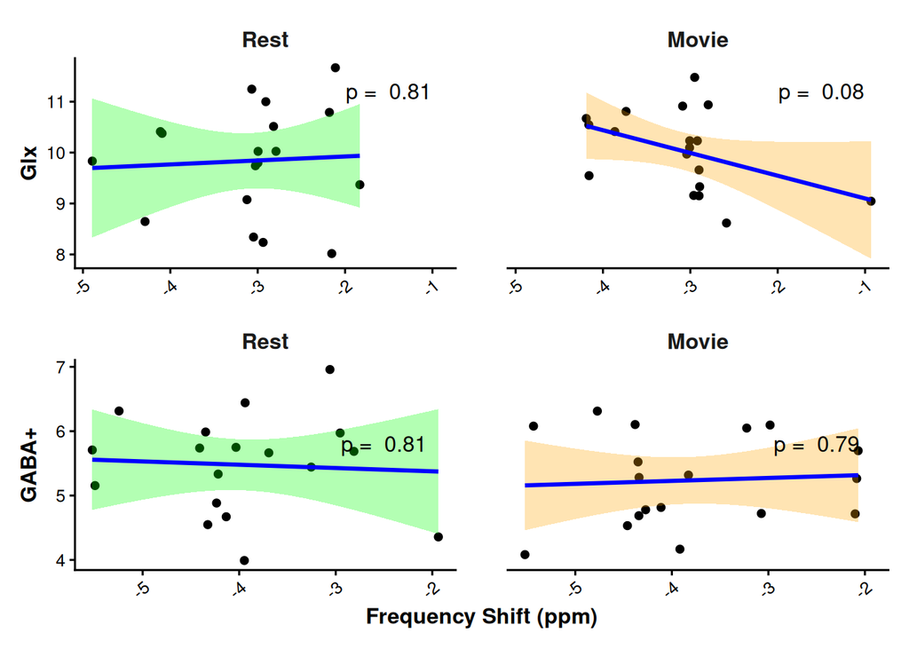

```r
(glxandgabaplus_freqshift_plot <- glx_freqshift_plot / gabaplus_freqshift_plot + plot_layout(guides = 'auto', axes = 'collect', axis_titles = 'collect'))
```

Are FWHM different between MEGAPRESS and sLASER?

```
In [71]:
```

```r
t.test(df$Rest_laser_osprey_waterfwhm, df$Rest_mega_osprey_waterfwhm)
```

```
    Welch Two Sample t-test

data:  df$Rest_laser_osprey_waterfwhm and df$Rest_mega_osprey_waterfwhm
t = 2.4854, df = 32.771, p-value = 0.01822
alternative hypothesis: true difference in means is not equal to 0
95 percent confidence interval:
 0.1105438 1.1096754
sample estimates:
mean of x mean of y
 8.467448  7.857338
```

```r
t.test(df$Movie_laser_osprey_waterfwhm, df$Movie_mega_osprey_waterfwhm)
```

```
    Welch Two Sample t-test

data:  df$Movie_laser_osprey_waterfwhm and df$Movie_mega_osprey_waterfwhm
t = 1.4465, df = 33.435, p-value = 0.1573
alternative hypothesis: true difference in means is not equal to 0
95 percent confidence interval:
 -0.1508480  0.8943228
sample estimates:
mean of x mean of y
 8.319767  7.948029
```

```
In [72]:
```

```r
freqshift_df <- dplyr::select(df, matches("freqshift")) %>% rename(Rest_freqshift_MEGAPRESS = Rest_mega_osprey_freqshift, Movie_freqshift_MEGAPRESS = Movie_mega_osprey_freqshift,
                                                                Rest_FreqShift_SLASER = Rest_laser_osprey_freqshift, Movie_FreqShift_SLASER = Movie_laser_osprey_freqshift) %>%
  reshape2::melt()
freqshift_df$Condition <- gsub("_.*", "", freqshift_df$variable)
freqshift_df$Method <- gsub(".*_.*_", "", freqshift_df$variable)
freqshift_df <- freqshift_df[, -1]
names(freqshift_df)[1] <- "freqshift"
freqshift_df$Condition <- factor(freqshift_df$Condition, levels = c("Rest", "Movie"))
```

Summary statistics:

```
In [73]:
```

```r
(freqshift_stats <- freqshift_df %>% group_by(Condition, Method) %>% summarise(mean = round(mean(freqshift), 2), sd = round(sd(freqshift), 2)))
```

```
# A tibble: 4 × 4
# Groups:   Condition [2]
  Condition Method     mean    sd
  <fct>     <chr>     <dbl> <dbl>
1 Rest      MEGAPRESS -3.98  0.94
2 Rest      SLASER    -3.08  0.81
3 Movie     MEGAPRESS -3.85  1.05
4 Movie     SLASER    -3.12  0.76
```

# Results

Let’s move on to results! How does Hurst change with condition?

```
In [74]:
```

```r
hurst_df <- dplyr::select(df, Subject, Rest_Hurst, Movie_Hurst)
hurst_effect_size <- cohensD(hurst_df$Rest_Hurst, hurst_df$Movie_Hurst)
(ttest_hurst <- t.test(hurst_df$Rest_Hurst, hurst_df$Movie_Hurst, paired = TRUE))
```

```
    Paired t-test

data:  hurst_df$Rest_Hurst and hurst_df$Movie_Hurst
t = -3.7337, df = 17, p-value = 0.001652
alternative hypothesis: true mean difference is not equal to 0
95 percent confidence interval:
 -0.1205405 -0.0334974
sample estimates:
mean difference
    -0.07701894
```

```r
hurst_stats <- hurst_df
```

```
In [75]:
```

```r
hurst_df <- reshape2::melt(hurst_df, id.vars = c("Subject"))
hurst_df$variable <- gsub("_.*", "", hurst_df$variable)
names(hurst_df) <- c("Sub", "Condition", "Hurst")
hurst_df$Condition <- factor(hurst_df$Condition, levels = c("Rest", "Movie"))

#hurst_df$Sex <- sub_dem$Sex
hurst_df <- hurst_df %>% left_join(sub_dem, by = c("Sub" = "Subject"))

hurst_m <- hurst_df %>% dplyr::filter(Sex == "M")
hurst_f <- hurst_df %>% dplyr::filter(Sex == "F")
t.test(hurst_m$Hurst, hurst_f$Hurst)
```

```
    Welch Two Sample t-test

data:  hurst_m$Hurst and hurst_f$Hurst
t = 1.0111, df = 20.502, p-value = 0.3238
alternative hypothesis: true difference in means is not equal to 0
95 percent confidence interval:
 -0.04407192  0.12723430
sample estimates:
mean of x mean of y
 1.039278  0.997697
```

```r
hurst_df$Age <- sub_dem$Age
cor.test(hurst_df$Hurst, hurst_df$Age)
```

```
    Pearson's product-moment correlation

data:  hurst_df$Hurst and hurst_df$Age
t = -1.2414, df = 34, p-value = 0.223
alternative hypothesis: true correlation is not equal to 0
95 percent confidence interval:
 -0.5023938  0.1291436
sample estimates:
       cor
-0.2082268
```

```r
deltaH <- df$Movie_Hurst - df$Rest_Hurst
deltaH_df <- data.frame(deltaH, sub_dem$Sex, sub_dem$Age)
names(deltaH_df) <- c("deltaH", "Sex", "Age")
deltaH_m <- deltaH_df %>% dplyr::filter(Sex == "M")
deltaH_f <- deltaH_df %>% dplyr::filter(Sex == "F")
t.test(deltaH_m$deltaH, deltaH_f$deltaH)
```

```
    Welch Two Sample t-test

data:  deltaH_m$deltaH and deltaH_f$deltaH
t = 1.3984, df = 12.902, p-value = 0.1856
alternative hypothesis: true difference in means is not equal to 0
95 percent confidence interval:
 -0.03170098  0.14781153
sample estimates:
mean of x mean of y
0.1092719 0.0512166
```

```r
cor.test(deltaH_df$deltaH, deltaH_df$Age)
```

```
    Pearson's product-moment correlation

data:  deltaH_df$deltaH and deltaH_df$Age
t = 1.2092, df = 16, p-value = 0.2441
alternative hypothesis: true correlation is not equal to 0
95 percent confidence interval:
 -0.2052194  0.6662368
sample estimates:
     cor
0.289376
```

```
In [76]:
```

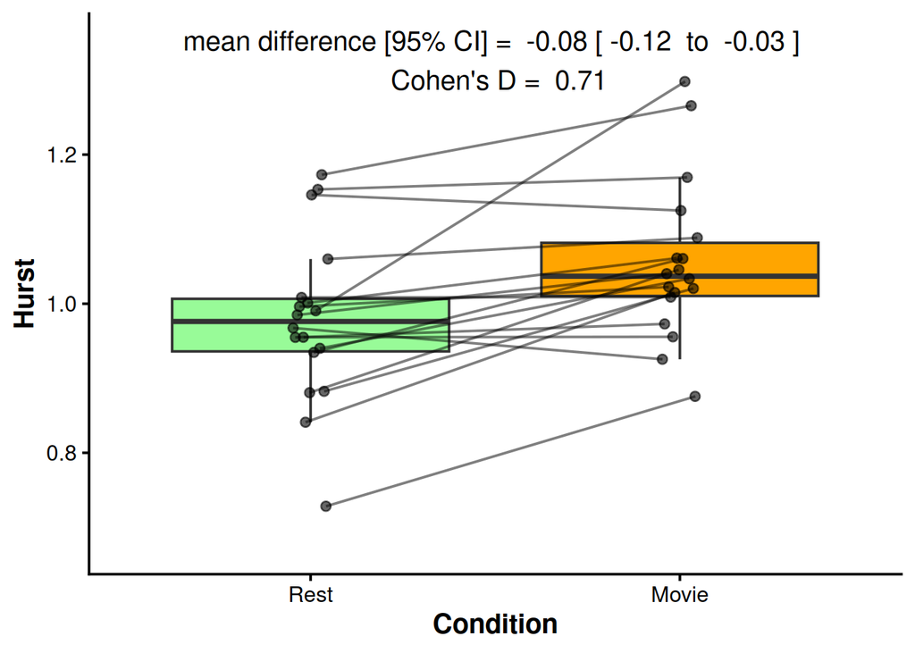

```r
minmax <- c(min(hurst_df$Hurst), max(hurst_df$Hurst))
space <- (minmax[2] - minmax[1]) / 10
(hurst_boxplot <- ggplot(hurst_df, aes(x = Condition, y = Hurst, fill = Condition)) +
  geom_boxplot(outlier.shape = NA) +
  geom_point(alpha = 0.6, position = position_jitterdodge(dodge.width = 0.1, jitter.width = 0.01, seed = 123), aes(group = Sub)) +
  geom_line(aes(group = Sub), position = position_jitterdodge(dodge.width = 0.1, jitter.width = 0.01, seed = 123), alpha = 0.5) +
  scale_fill_manual(values = c("#98FB98", "#FFA500"), guide = "none") +
  theme_classic(base_size = 15) +
  ylim(minmax[1] - space, minmax[2] + space) +
  theme(axis.title = element_text(face = "bold"), legend.position = "none") +
  annotate(geom = "text", x = 1.5, y = minmax[2] + space / 2, label = paste(
    # roundedpvalue,
    "mean difference [95% CI] = ",
    round(as.numeric(ttest_hurst$estimate), 2),
    "[",
    round(as.numeric(ttest_hurst$conf.int)[1], 2),
    " to ",
    round(as.numeric(ttest_hurst$conf.int)[2], 2),
    "]",
    "\n Cohen's D = ",
    round(hurst_effect_size, 2)
  ))
)
```

```r
png(file = "HE_v_Condition_Plot.png", width = 7, height = 4, units = "in", res = 300)
hurst_boxplot
dev.off()
```

## Glx

How does glx change with condition?

```
In [77]:
```

```r
glx_df <- dplyr::select(df, Subject, Rest_laser_osprey_glx, Movie_laser_osprey_glx)
glx_effect_size <- cohensD(glx_df$Rest_laser_osprey_glx, glx_df$Movie_laser_osprey_glx)
(ttest_glx <- t.test(glx_df$Rest_laser_osprey_glx, glx_df$Movie_laser_osprey_glx, paired = TRUE))
```

```
    Paired t-test

data:  glx_df$Rest_laser_osprey_glx and glx_df$Movie_laser_osprey_glx
t = -1.1552, df = 17, p-value = 0.264
alternative hypothesis: true mean difference is not equal to 0
95 percent confidence interval:
 -0.5800182  0.1695861
sample estimates:
mean difference
     -0.2052161
```

```r
glx_df <- reshape2::melt(glx_df, id.vars = c("Subject"))
glx_df$variable <- gsub("_.*", "", glx_df$variable)
names(glx_df) <- c("Sub", "Condition", "Glx")
glx_df$Condition <- factor(glx_df$Condition, levels = c("Rest", "Movie"))

glx_df$Sex <- sub_dem$Sex
glx_m <- glx_df %>% dplyr::filter(Sex == "M")
glx_f <- glx_df %>% dplyr::filter(Sex == "F")
t.test(glx_m$Glx, glx_f$Glx)
```

```
    Welch Two Sample t-test

data:  glx_m$Glx and glx_f$Glx
t = 1.0399, df = 31.08, p-value = 0.3064
alternative hypothesis: true difference in means is not equal to 0
95 percent confidence interval:
 -0.3128285  0.9638601
sample estimates:
mean of x mean of y
10.122567  9.797051
```

```r
glx_df$Age <- sub_dem$Age
cor.test(glx_df$Glx, glx_df$Age)
```

```
    Pearson's product-moment correlation

data:  glx_df$Glx and glx_df$Age
t = -1.0756, df = 34, p-value = 0.2897
alternative hypothesis: true correlation is not equal to 0
95 percent confidence interval:
 -0.4812534  0.1564619
sample estimates:
       cor
-0.1813984
```

```
In [78]:
```

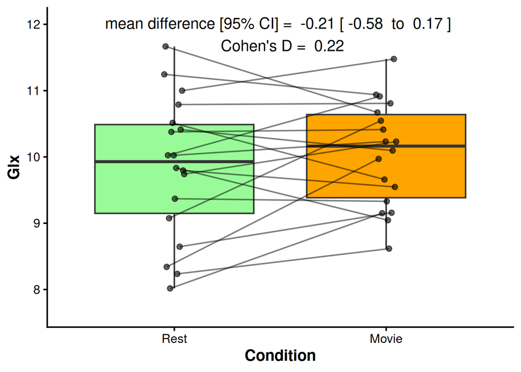

```r
minmax <- c(min(glx_df$Glx), max(glx_df$Glx))
space <- (minmax[2] - minmax[1]) / 10
(glx_boxplot <- ggplot(glx_df, aes(x = Condition, y = Glx, fill = Condition)) +
  scale_fill_manual(values = c("#98FB98", "#FFA500"), guide = "none") +
  theme_classic(base_size = 15) +
  theme(axis.title = element_text(face = "bold"), legend.position = "none") +
  geom_boxplot(outlier.shape = NA) +
  geom_point(alpha = 0.6, position = position_jitterdodge(dodge.width = 0.1, jitter.width = 0.01, seed = 123), aes(group = Sub)) +
  geom_line(aes(group = Sub), position = position_jitterdodge(dodge.width = 0.1, jitter.width = 0.01, seed = 123), alpha = 0.5) +
  ylab("Glx") +
  ylim(minmax[1] - space, minmax[2] + space) +
  annotate(geom = "text", x = 1.5, y = minmax[2] + space / 2, label = paste(
    "mean difference [95% CI] = ",
    round(as.numeric(ttest_glx$estimate), 2),
    "[",
    round(as.numeric(ttest_glx$conf.int)[1], 2),
    " to ",
    round(as.numeric(ttest_glx$conf.int)[2], 2),
    "]",
    "\n Cohen's D = ",
    round(glx_effect_size, 2)
  ))
)
```

```r
png(file = "glx_v_Condition_Plot.png", width = 7, height = 4, units = "in", res = 300)
glx_boxplot
dev.off()
```

```r
t.test(df$Rest_laser_osprey_glx, df$Movie_laser_osprey_glx, paired = T)
```

```
    Paired t-test

data:  df$Rest_laser_osprey_glx and df$Movie_laser_osprey_glx
t = -1.1552, df = 17, p-value = 0.264
alternative hypothesis: true mean difference is not equal to 0
95 percent confidence interval:
 -0.5800182  0.1695861
sample estimates:
mean difference
     -0.2052161
```

```
In [79]:
```

```r
(glx_stats <- glx_df %>% group_by(Condition) %>% summarise(mean = round(mean(Glx), 2), sd = round(sd(Glx), 2)))
```

```
# A tibble: 2 × 3
  Condition  mean    sd
  <fct>     <dbl> <dbl>
1 Rest       9.84  1.06
2 Movie     10.0   0.79
```

```
In [80]:
```

```r
crlbglx_df <- df %>% dplyr::select(Subject, Rest_laser_osprey_glx_CRLB, Movie_laser_osprey_glx_CRLB)
crlbglx_df <- reshape2::melt(crlbglx_df, id.vars = c("Subject"))
crlbglx_df$variable <- gsub("_.*", "", crlbglx_df$variable)
names(crlbglx_df) <- c("Sub", "Condition", "CRLB")
crlbglx_df$Condition <- factor(crlbglx_df$Condition, levels = c("Rest", "Movie"))
(crlbglx_stats <- crlbglx_df %>% group_by(Condition) %>% summarise(mean = round(mean(CRLB), 2), sd = round(sd(CRLB), 2)))
```

```
# A tibble: 2 × 3
  Condition  mean    sd
  <fct>     <dbl> <dbl>
1 Rest       4.39  0.5
2 Movie      4.17  0.51
```

## Glu

How does glu change with condition?

```
In [81]:
```

```r
glu_df <- dplyr::select(df, Subject, Rest_laser_osprey_glu, Movie_laser_osprey_glu)
glu_effect_size <- cohensD(glu_df$Rest_laser_osprey_glu, glu_df$Movie_laser_osprey_glu)
(ttest_glu <- t.test(glu_df$Rest_laser_osprey_glu, glu_df$Movie_laser_osprey_glu, paired = TRUE))
```

```
    Paired t-test

data:  glu_df$Rest_laser_osprey_glu and glu_df$Movie_laser_osprey_glu
t = -0.75941, df = 17, p-value = 0.458
alternative hypothesis: true mean difference is not equal to 0
95 percent confidence interval:
 -0.3467063  0.1631780
sample estimates:
mean difference
    -0.09176418
```

```r
glu_df <- reshape2::melt(glu_df, id.vars = c("Subject"))
glu_df$variable <- gsub("_.*", "", glu_df$variable)
names(glu_df) <- c("Sub", "Condition", "Glu")
glu_df$Condition <- factor(glu_df$Condition, levels = c("Rest", "Movie"))

glu_df$Sex <- sub_dem$Sex
glu_m <- glu_df %>% dplyr::filter(Sex == "M")
glu_f <- glu_df %>% dplyr::filter(Sex == "F")
t.test(glu_m$Glu, glu_f$Glu)
```

```
    Welch Two Sample t-test

data:  glu_m$Glu and glu_f$Glu
t = -0.01106, df = 30.305, p-value = 0.9912
alternative hypothesis: true difference in means is not equal to 0
95 percent confidence interval:
 -0.4653892  0.4603735
sample estimates:
mean of x mean of y
 7.067663  7.070171
```

```r
glu_df$Age <- sub_dem$Age
cor.test(glu_df$Glu, glu_df$Age)
```

```
    Pearson's product-moment correlation

data:  glu_df$Glu and glu_df$Age
t = -1.5837, df = 34, p-value = 0.1225
alternative hypothesis: true correlation is not equal to 0
95 percent confidence interval:
 -0.5438161  0.0726851
sample estimates:
       cor
-0.2621097
```

```
In [82]:
```

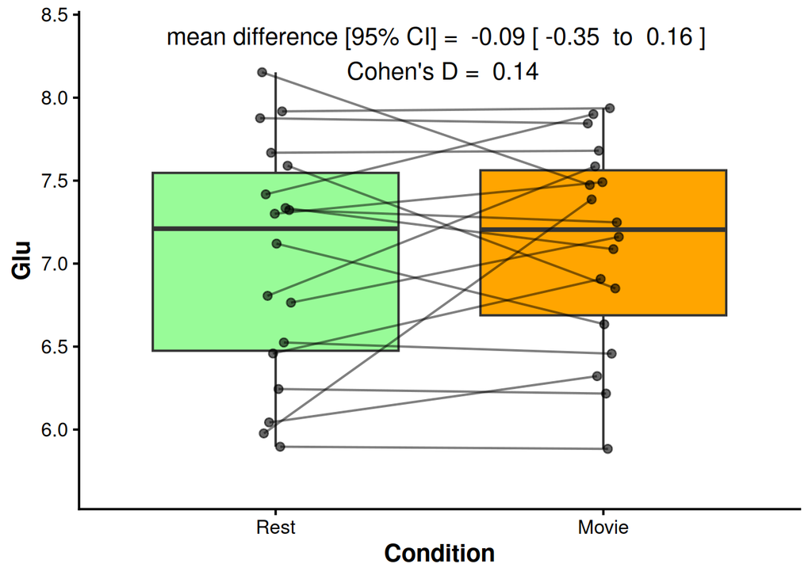

```r
minmax <- c(min(glu_df$Glu), max(glu_df$Glu))
space <- (minmax[2] - minmax[1]) / 10
(glu_boxplot <- ggplot(glu_df, aes(x = Condition, y = Glu, fill = Condition)) +
  scale_fill_manual(values = c("#98FB98", "#FFA500"), guide = "none") +
  theme_classic(base_size = 15) +
  theme(axis.title = element_text(face = "bold"), legend.position = "none") +
  geom_boxplot(outlier.shape = NA) +
  geom_point(alpha = 0.6, position = position_jitterdodge(dodge.width = 0.1, jitter.width = 0.01, seed = 123), aes(group = Sub)) +
  geom_line(aes(group = Sub), position = position_jitterdodge(dodge.width = 0.1, jitter.width = 0.01, seed = 123), alpha = 0.5) +
  ylab("Glu") +
  ylim(minmax[1] - space, minmax[2] + space) +
  annotate(geom = "text", x = 1.5, y = minmax[2] + space / 2, label = paste(
    "mean difference [95% CI] = ",
    round(as.numeric(ttest_glu$estimate), 2),
    "[",
    round(as.numeric(ttest_glu$conf.int)[1], 2),
    " to ",
    round(as.numeric(ttest_glu$conf.int)[2], 2),
    "]",
    "\n Cohen's D = ",
    round(glu_effect_size, 2)
  ))
)
```

```r
png(file = "Glu_v_Condition_Plot.png", width = 7, height = 4, units = "in", res = 300)
glu_boxplot
dev.off()
```

```r
t.test(df$Rest_laser_osprey_glu, df$Movie_laser_osprey_glu, paired = T)
```

```
    Paired t-test

data:  df$Rest_laser_osprey_glu and df$Movie_laser_osprey_glu
t = -0.75941, df = 17, p-value = 0.458
alternative hypothesis: true mean difference is not equal to 0
95 percent confidence interval:
 -0.3467063  0.1631780
sample estimates:
mean difference
    -0.09176418
```

```
In [83]:
```

```r
(glu_stats <- glu_df %>% group_by(Condition) %>% summarise(mean = round(mean(Glu), 2), sd = round(sd(Glu), 2)))
```

```
# A tibble: 2 × 3
  Condition  mean    sd
  <fct>     <dbl> <dbl>
1 Rest       7.02  0.71
2 Movie      7.11  0.62
```

```
In [84]:
```

```r
crlbglu_df <- df %>% dplyr::select(Subject, Rest_laser_osprey_glu_CRLB, Movie_laser_osprey_glu_CRLB)
crlbglu_df <- reshape2::melt(crlbglu_df, id.vars = c("Subject"))
crlbglu_df$variable <- gsub("_.*", "", crlbglu_df$variable)
names(crlbglu_df) <- c("Sub", "Condition", "CRLB")
crlbglu_df$Condition <- factor(crlbglu_df$Condition, levels = c("Rest", "Movie"))
(crlbglu_stats <- crlbglu_df %>% group_by(Condition) %>% summarise(mean = round(mean(CRLB), 2), sd = round(sd(CRLB), 2)))
```

```
# A tibble: 2 × 3
  Condition  mean    sd
  <fct>     <dbl> <dbl>
1 Rest       4.33  0.49
2 Movie      4.17  0.51
```

## GABA

How does GABA change with condition?

```
In [85]:
```

```r
gaba_df <- dplyr::select(df, Subject, Rest_mega_osprey_gaba, Movie_mega_osprey_gaba)
gaba_effect_size <- cohensD(gaba_df$Rest_mega_osprey_gaba, gaba_df$Movie_mega_osprey_gaba)
(ttest_gaba <- t.test(gaba_df$Rest_mega_osprey_gaba, gaba_df$Movie_mega_osprey_gaba, paired = TRUE))
```

```
    Paired t-test

data:  gaba_df$Rest_mega_osprey_gaba and gaba_df$Movie_mega_osprey_gaba
t = 0.81494, df = 17, p-value = 0.4264
alternative hypothesis: true mean difference is not equal to 0
95 percent confidence interval:
 -0.1492674  0.3371529
sample estimates:
mean difference
     0.09394271
```

```r
gaba_df <- reshape2::melt(gaba_df, id.vars = c("Subject"))
gaba_df$variable <- gsub("_.*", "", gaba_df$variable)
names(gaba_df) <- c("Sub", "Condition", "gaba")
gaba_df$Condition <- factor(gaba_df$Condition, levels = c("Rest", "Movie"))

gaba_df$Sub <- gaba_df$Sub
gaba_df$Sex <- sub_dem$Sex
gaba_m <- gaba_df %>% dplyr::filter(Sex == "M")
gaba_f <- gaba_df %>% dplyr::filter(Sex == "F")
t.test(gaba_m$gaba, gaba_f$gaba)
```

```
    Welch Two Sample t-test

data:  gaba_m$gaba and gaba_f$gaba
t = -0.0026193, df = 22.151, p-value = 0.9979
alternative hypothesis: true difference in means is not equal to 0
95 percent confidence interval:
 -0.2972427  0.2964925
sample estimates:
mean of x mean of y
 1.594311  1.594687
```

```r
gaba_df$Age <- sub_dem$Age
cor.test(gaba_df$gaba, gaba_df$Age)
```

```
    Pearson's product-moment correlation

data:  gaba_df$gaba and gaba_df$Age
t = -2.3422, df = 34, p-value = 0.02517
alternative hypothesis: true correlation is not equal to 0
95 percent confidence interval:
 -0.62476510 -0.05036861
sample estimates:
       cor
-0.3727363
```

```
In [86]:
```

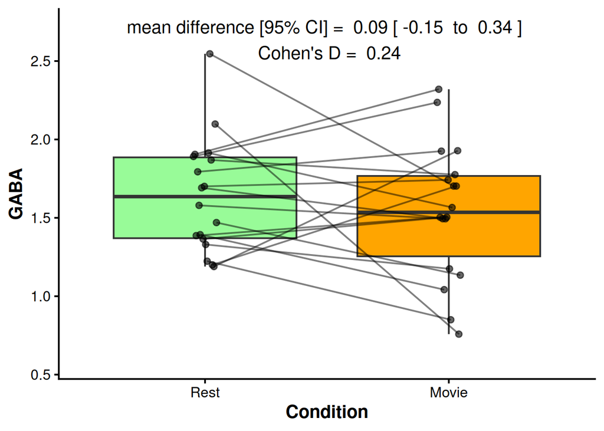

```r
minmax <- c(min(gaba_df$gaba), max(gaba_df$gaba))
space <- (minmax[2] - minmax[1]) / 10
(gaba_boxplot <- ggplot(gaba_df, aes(x = Condition, y = gaba, fill = Condition)) +
  scale_fill_manual(values = c("#98FB98", "#FFA500"), guide = "none") +
  theme_classic(base_size = 15) +
  ylab("GABA") +
  theme(axis.title = element_text(face = "bold"), legend.position = "none") +
  geom_boxplot(outlier.shape = NA) +
  geom_point(alpha = 0.6, position = position_jitterdodge(dodge.width = 0.1, jitter.width = 0.01, seed = 123), aes(group = Sub)) +
  geom_line(aes(group = Sub), position = position_jitterdodge(dodge.width = 0.1, jitter.width = 0.01, seed = 123), alpha = 0.5) +
  ylim(minmax[1] - space, minmax[2] + space) +
  annotate(geom = "text", x = 1.5, y = minmax[2] + space / 2, label = paste(
    "mean difference [95% CI] = ",
    round(as.numeric(ttest_gaba$estimate), 2),
    "[",
    round(as.numeric(ttest_gaba$conf.int)[1], 2),
    " to ",
    round(as.numeric(ttest_gaba$conf.int)[2], 2),
    "]",
    "\n Cohen's D = ",
    round(gaba_effect_size, 2)
  ))
)
```

```r
png(file = "gaba_v_Condition_Plot.png", width = 7, height = 4, units = "in", res = 300)
gaba_boxplot
dev.off()
```

```
In [87]:
```

```r
(gaba_stats <- gaba_df %>% group_by(Condition) %>% summarise(mean = round(mean(gaba), 2), sd = round(sd(gaba), 2)))
```

```
# A tibble: 2 × 3
  Condition  mean    sd
  <fct>     <dbl> <dbl>
1 Rest       1.64  0.36
2 Movie      1.55  0.43
```

```
In [88]:
```

```r
crlbgaba_df <- df %>% dplyr::select(Subject, Rest_mega_osprey_gaba_CRLB, Movie_mega_osprey_gaba_CRLB)
crlbgaba_df <- reshape2::melt(crlbgaba_df, id.vars = c("Subject"))
crlbgaba_df$variable <- gsub("_.*", "", crlbgaba_df$variable)
names(crlbgaba_df) <- c("Sub", "Condition", "CRLB")
crlbgaba_df$Condition <- factor(crlbgaba_df$Condition, levels = c("Rest", "Movie"))
(crlbgaba_stats <- crlbgaba_df %>% group_by(Condition) %>% summarise(mean = round(mean(CRLB), 2), sd = round(sd(CRLB), 2)))
```

```
# A tibble: 2 × 3
  Condition  mean    sd
  <fct>     <dbl> <dbl>
1 Rest       16.6  5.51
2 Movie      18.5  5.86
```

## GABA+

How does GABA change with condition?

```
In [89]:
```

```r
gabaplus_df <- dplyr::select(df, Subject, Rest_mega_osprey_gabaplus, Movie_mega_osprey_gabaplus)
gabaplus_effect_size <- cohensD(gabaplus_df$Rest_mega_osprey_gabaplus, gabaplus_df$Movie_mega_osprey_gabaplus)
(ttest_gabaplus <- t.test(gabaplus_df$Rest_mega_osprey_gabaplus, gabaplus_df$Movie_mega_osprey_gabaplus, paired = TRUE))
```

```
    Paired t-test

data:  gabaplus_df$Rest_mega_osprey_gabaplus and gabaplus_df$Movie_mega_osprey_gabaplus
t = 1.433, df = 17, p-value = 0.17
alternative hypothesis: true mean difference is not equal to 0
95 percent confidence interval:
 -0.1148642  0.6012634
sample estimates:
mean difference
      0.2431996
```

```r
gabaplus_df <- reshape2::melt(gabaplus_df, id.vars = c("Subject"))
gabaplus_df$variable <- gsub("_.*", "", gabaplus_df$variable)
names(gabaplus_df) <- c("Sub", "Condition", "GABAplus")
gabaplus_df$Condition <- factor(gabaplus_df$Condition, levels = c("Rest", "Movie"))

gabaplus_df$Sub <- gabaplus_df$Sub
gabaplus_df$Sex <- sub_dem$Sex
gabaplus_m <- gabaplus_df %>% dplyr::filter(Sex == "M")
gabaplus_f <- gabaplus_df %>% dplyr::filter(Sex == "F")
t.test(gabaplus_m$GABAplus, gabaplus_f$GABAplus)
```

```
    Welch Two Sample t-test

data:  gabaplus_m$GABAplus and gabaplus_f$GABAplus
t = -0.3602, df = 33.18, p-value = 0.721
alternative hypothesis: true difference in means is not equal to 0
95 percent confidence interval:
 -0.5959995  0.4166759
sample estimates:
mean of x mean of y
 5.306332  5.395993
```

```r
gabaplus_df$Age <- sub_dem$Age
cor.test(gabaplus_df$GABAplus, gabaplus_df$Age)
```

```
    Pearson's product-moment correlation

data:  gabaplus_df$GABAplus and gabaplus_df$Age
t = -0.43113, df = 34, p-value = 0.6691
alternative hypothesis: true correlation is not equal to 0
95 percent confidence interval:
 -0.3927587  0.2611239
sample estimates:
        cor
-0.07373768
```

```
In [90]:
```

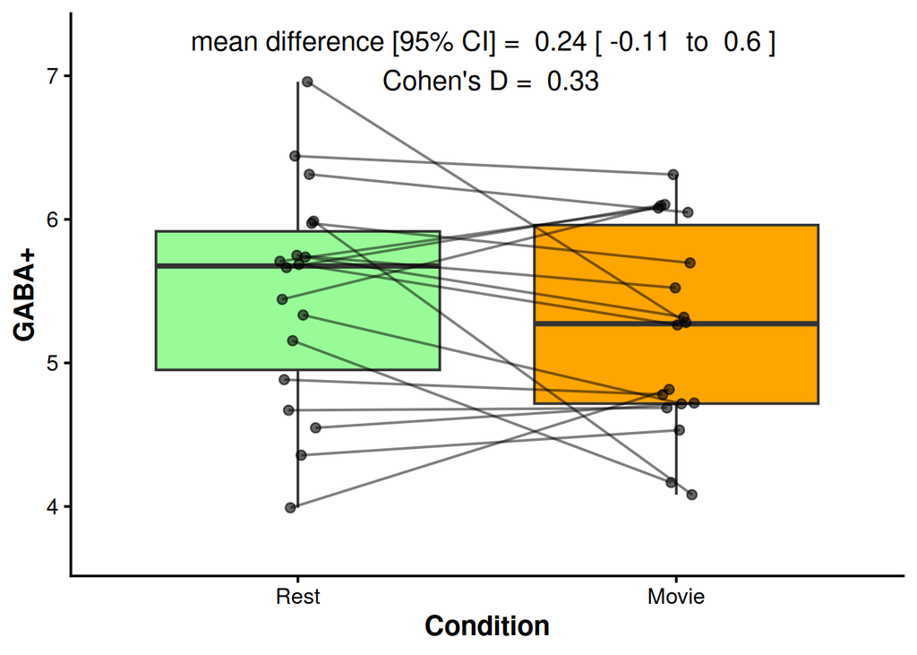

```r
minmax <- c(min(gabaplus_df$GABAplus), max(gabaplus_df$GABAplus))
space <- (minmax[2] - minmax[1]) / 10
(gabaplus_boxplot <- ggplot(gabaplus_df, aes(x = Condition, y = GABAplus, fill = Condition)) +
  scale_fill_manual(values = c("#98FB98", "#FFA500"), guide = "none") +
  theme_classic(base_size = 15) +
  ylab("GABA+") +
  theme(axis.title = element_text(face = "bold"), legend.position = "none") +
  geom_boxplot(outlier.shape = NA) +
  geom_point(alpha = 0.6, position = position_jitterdodge(dodge.width = 0.1, jitter.width = 0.01, seed = 123), aes(group = Sub)) +
  geom_line(aes(group = Sub), position = position_jitterdodge(dodge.width = 0.1, jitter.width = 0.01, seed = 123), alpha = 0.5) +
  ylim(minmax[1] - space, minmax[2] + space) +
  annotate(geom = "text", x = 1.5, y = minmax[2] + space / 2, label = paste(
    "mean difference [95% CI] = ",
    round(as.numeric(ttest_gabaplus$estimate), 2),
    "[",
    round(as.numeric(ttest_gabaplus$conf.int)[1], 2),
    " to ",
    round(as.numeric(ttest_gabaplus$conf.int)[2], 2),
    "]",
    "\n Cohen's D = ",
    round(gabaplus_effect_size, 2)
  ))
)
```

```r
png(file = "GABAplus_v_Condition_Plot.png", width = 7, height = 4, units = "in", res = 300)
gabaplus_boxplot
dev.off()
```

```
In [91]:
```

```r
(gabaplus_stats <- gabaplus_df %>% group_by(Condition) %>% summarise(mean = round(mean(GABAplus), 2), sd = round(sd(GABAplus), 2)))
```

```
# A tibble: 2 × 3
  Condition  mean    sd
  <fct>     <dbl> <dbl>
1 Rest       5.48  0.77
2 Movie      5.23  0.71
```

```
In [92]:
```

```r
crlbgabaplus_df <- df %>% dplyr::select(Subject, Rest_mega_osprey_gabaplus_CRLB, Movie_mega_osprey_gabaplus_CRLB)
crlbgabaplus_df <- reshape2::melt(crlbgabaplus_df, id.vars = c("Subject"))
crlbgabaplus_df$variable <- gsub("_.*", "", crlbgabaplus_df$variable)
names(crlbgabaplus_df) <- c("Sub", "Condition", "CRLB")
crlbgabaplus_df$Condition <- factor(crlbgabaplus_df$Condition, levels = c("Rest", "Movie"))
(crlbgabaplus_stats <- crlbgabaplus_df %>% group_by(Condition) %>% summarise(mean = round(mean(CRLB), 2), sd = round(sd(CRLB), 2)))
```

```
# A tibble: 2 × 3
  Condition  mean    sd
  <fct>     <dbl> <dbl>
1 Rest       9.94  2.21
2 Movie     10.4   1.5
```

## EI

How does EI change with condition?

```
In [93]:
```

```r
ei_df <- as.data.frame(glx_df$Glx / gabaplus_df$GABAplus)
ei_df$Condition <- gabaplus_df$Condition
names(ei_df)[1] <- "EI"
rest_ei <- ei_df %>% dplyr::filter(Condition == "Rest")
rest_ei <- rest_ei[, 1]
movie_ei <- ei_df %>% dplyr::filter(Condition == "Movie")
movie_ei <- movie_ei[, 1]
ei_effect_size <- cohensD(rest_ei, movie_ei)
(ttest_ei <- t.test(rest_ei, movie_ei, paired = TRUE))
```

```
    Paired t-test

data:  rest_ei and movie_ei
t = -1.8573, df = 17, p-value = 0.08069
alternative hypothesis: true mean difference is not equal to 0
95 percent confidence interval:
 -0.26516338  0.01688153
sample estimates:
mean difference
     -0.1241409
```

```r
ei_df$Condition <- factor(ei_df$Condition, levels = c("Rest", "Movie"))
ei_df$Sub <- gabaplus_df$Sub
ei_df$Sex <- sub_dem$Sex
ei_m <- ei_df %>% dplyr::filter(Sex == "M")
ei_f <- ei_df %>% dplyr::filter(Sex == "F")
t.test(ei_m$EI, ei_f$EI)
```

```
    Welch Two Sample t-test

data:  ei_m$EI and ei_f$EI
t = 1.0157, df = 33.366, p-value = 0.3171
alternative hypothesis: true difference in means is not equal to 0
95 percent confidence interval:
 -0.08624298  0.25834031
sample estimates:
mean of x mean of y
 1.930566  1.844517
```

```r
ei_df$Age <- sub_dem$Age
cor.test(ei_df$EI, ei_df$Age)
```

```
    Pearson's product-moment correlation

data:  ei_df$EI and ei_df$Age
t = 0.08138, df = 34, p-value = 0.9356
alternative hypothesis: true correlation is not equal to 0
95 percent confidence interval:
 -0.3160295  0.3409278
sample estimates:
       cor
0.01395512
```

```
In [94]:
```

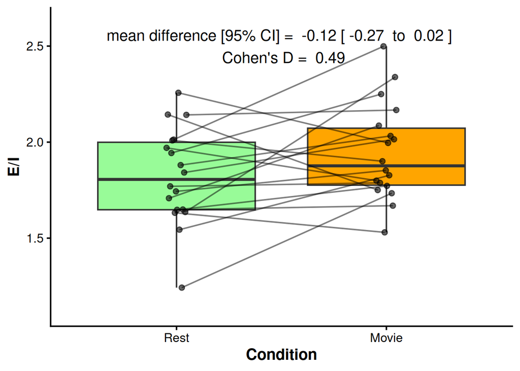

```r
minmax <- c(min(ei_df$EI), max(ei_df$EI))
space <- (minmax[2] - minmax[1]) / 10
(ei_boxplot <- ggplot(ei_df, aes(x = Condition, y = EI, fill = Condition)) +
  scale_fill_manual(values = c("#98FB98", "#FFA500"), guide = "none") +
  ylab("E/I") +
  theme_classic(base_size = 15) +
  theme(axis.title = element_text(face = "bold"), legend.position = "none") +
  geom_boxplot(outlier.shape = NA) +
  geom_point(alpha = 0.6, position = position_jitterdodge(dodge.width = 0.1, jitter.width = 0.01, seed = 123), aes(group = Sub)) +
  geom_line(aes(group = Sub), position = position_jitterdodge(dodge.width = 0.1, jitter.width = 0.01, seed = 123), alpha = 0.5) +
  ylim(minmax[1] - space, minmax[2] + space) +
  annotate(geom = "text", x = 1.5, y = minmax[2], label = paste(
    "mean difference [95% CI] = ",
    round(as.numeric(ttest_ei$estimate), 2),
    "[",
    round(as.numeric(ttest_ei$conf.int)[1], 2),
    " to ",
    round(as.numeric(ttest_ei$conf.int)[2], 2),
    "]",
    "\n Cohen's D = ",
    round(ei_effect_size, 2)
  ))
)
```

```r
png(file = "EI_Boxplot.png", width = 7, height = 4, units = "in", res = 300)
ei_boxplot
dev.off()
```

```
In [95]:
```

```r
(ei_stats <- ei_df %>% group_by(Condition) %>% summarise(mean = round(mean(EI), 2), sd = round(sd(EI), 2)))
```

```
# A tibble: 2 × 3
  Condition  mean    sd
  <fct>     <dbl> <dbl>
1 Rest       1.82  0.25
2 Movie      1.94  0.25
```

```
In [96]:
```

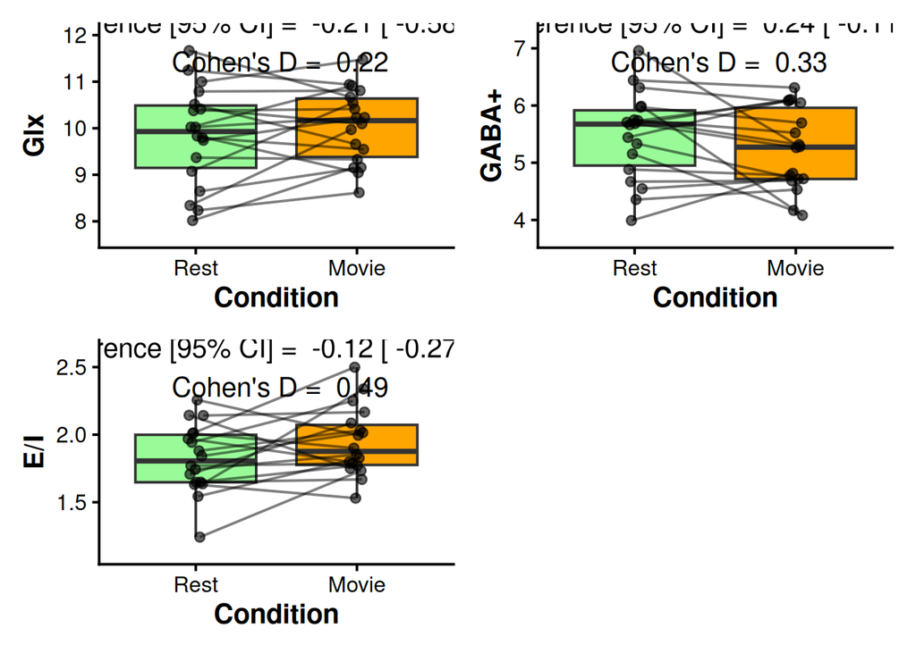

```r
(mrsresults_plot <- glx_boxplot + gabaplus_boxplot + ei_boxplot + plot_layout(ncol=2))
```

```r
ggsave("MRSResults_plot.png", plot = mrsresults_plot, width = 11, height = 9, dpi = 300, units = "in")
```

Is Hurst correlated with glx?

```
In [97]:
```

```r
glx <- dplyr::select(df, Rest_laser_osprey_glx, Movie_laser_osprey_glx)
glx_cond <- glx
glx <- reshape2::melt(glx)
glx_cond <- reshape2::melt(glx_cond)
glx <- glx[, -1]
glx_cond$Condition <- gsub("_.*", "", glx_cond$variable)
glx_cond <- glx_cond[, -1]
names(glx_cond)[1] <- "Glx"
hurst <- dplyr::select(df, Rest_Hurst, Movie_Hurst)
hurst <- reshape2::melt(hurst)
hurst_cond <- hurst
hurst <- hurst[, -1]
hurst_cond$Condition <- gsub("_.*", "", hurst_cond$variable)
hurst_cond <- hurst_cond[, -1]
names(hurst_cond)[1] <- "Hurst"
gh_df <- data.frame(hurst_cond$Condition, hurst_cond$Hurst, glx_cond$Glx)
names(gh_df) <- c("Condition", "Hurst", "Glx")

gh_rest <- dplyr::filter(gh_df, Condition == "Rest")
gh_rest_pearson <- cor.test(gh_rest$Hurst, gh_rest$Glx, method = "pearson")
print(gh_rest_pearson)
```

```
    Pearson's product-moment correlation

data:  gh_rest$Hurst and gh_rest$Glx
t = -0.0098423, df = 16, p-value = 0.9923
alternative hypothesis: true correlation is not equal to 0
95 percent confidence interval:
 -0.4687921  0.4649436
sample estimates:
         cor
-0.002460578
```

```r
gh_movie <- dplyr::filter(gh_df, Condition == "Movie")
gh_movie_pearson <- cor.test(gh_movie$Hurst, gh_movie$Glx, method = "pearson")
print(gh_movie_pearson)
```

```
    Pearson's product-moment correlation

data:  gh_movie$Hurst and gh_movie$Glx
t = -1.1191, df = 16, p-value = 0.2796
alternative hypothesis: true correlation is not equal to 0
95 percent confidence interval:
 -0.6540232  0.2258613
sample estimates:
       cor
-0.2694183
```

```
In [98]:
```

```r
glx_hurst_model <- lm(Hurst ~ Glx, data = gh_df)
(glx_hurst_model.summary <- summary(glx_hurst_model))
```

```
Call:
lm(formula = Hurst ~ Glx, data = gh_df)

Residuals:
      Min        1Q    Median        3Q       Max
-0.289098 -0.069645 -0.006342  0.042259  0.270913

Coefficients:
             Estimate Std. Error t value Pr(>|t|)
(Intercept)  1.098741   0.211000   5.207 9.25e-06 ***
Glx         -0.008305   0.021135  -0.393    0.697
---
Signif. codes:  0 '***' 0.001 '**' 0.01 '*' 0.05 '.' 0.1 ' ' 1

Residual standard error: 0.1158 on 34 degrees of freedom
Multiple R-squared:  0.004521,  Adjusted R-squared:  -0.02476
F-statistic: 0.1544 on 1 and 34 DF,  p-value: 0.6968
```

```
In [99]:
```

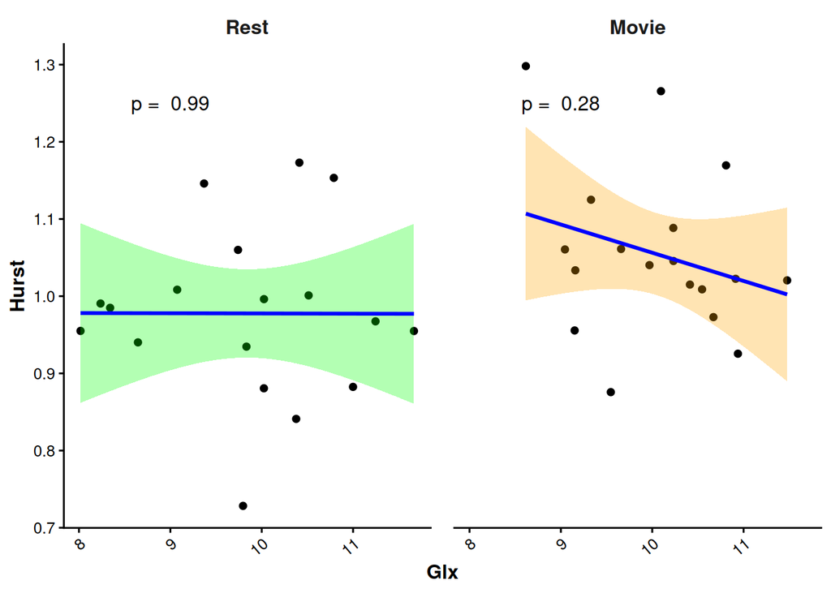

```r
dat_text <- data.frame(
  label = c(paste("p = ", round(gh_rest_pearson$p.value, 2)), paste("p = ", round(gh_movie_pearson$p.value, 2))),
  Condition = c("Rest", "Movie"),
  x = c(9, 9),
  y = c(1.25, 1.25)
)
(glx_hurst_plot <- ggplot(data = gh_df, aes(x = Glx, y = Hurst, color = Condition, fill = Condition)) +
  geom_point(color = "black") +
  geom_smooth(method = "lm", color = "blue", aes(fill = Condition), alpha = 0.3) +
  theme_classic(base_size = 12) +
  theme(
    strip.background = element_blank(), strip.text.x = element_text(size = 12, face = "bold"),
    axis.title = element_text(face = "bold"), legend.title = element_text(face = "bold")
  ) +
  theme(legend.position = "none") +
  xlab("Glx") +
  ylab("Hurst") +
  facet_wrap(~ factor(Condition, levels = c("Rest", "Movie"))) +
  geom_text(
    data = dat_text,
    mapping = aes(x = x, y = y, label = label),
    inherit.aes = FALSE
  ) +
  scale_x_continuous(guide = guide_axis(angle = 40)) +
  scale_fill_manual(values = c("Rest" = "green", "Movie" = "orange")) +
  theme(panel.spacing = unit(1, "lines"))
)
```

```r
png(file = "Glx_Hurst_Plot.png", width = 7, height = 4, units = "in", res = 300)
glx_hurst_plot
dev.off()
```

Is Hurst correlated with GABAplus?

```
In [100]:
```

```r
gabaplus <- dplyr::select(df, Rest_mega_osprey_gabaplus, Movie_mega_osprey_gabaplus)
gabaplus <- reshape2::melt(gabaplus)
gabaplus$Condition <- gsub("_.*", "", gabaplus$variable)
gabaplus <- gabaplus[, -1]
names(gabaplus)[1] <- "GABAplus"
gabaplush_df <- data.frame(hurst, gabaplus)
names(gabaplush_df)[1] <- "Hurst"
pearson_hurst_gabaplus <- cor.test(gabaplush_df$GABAplus, gabaplush_df$Hurst, method = "pearson")

gabaplush_rest <- dplyr::filter(gabaplush_df, Condition == "Rest")
gabaplush_rest_pearson <- cor.test(gabaplush_rest$Hurst, gabaplush_rest$GABAplus, method = "pearson")
print(gabaplush_rest_pearson)
```

```
    Pearson's product-moment correlation

data:  gabaplush_rest$Hurst and gabaplush_rest$GABAplus
t = 0.085385, df = 16, p-value = 0.933
alternative hypothesis: true correlation is not equal to 0
95 percent confidence interval:
 -0.4500124  0.4833952
sample estimates:
      cor
0.0213415
```

```r
gabaplush_movie <- dplyr::filter(gabaplush_df, Condition == "Movie")
gabaplush_movie_pearson <- cor.test(gabaplush_movie$Hurst, gabaplush_movie$GABAplus, method = "pearson")
print(gabaplush_movie_pearson)
```

```
    Pearson's product-moment correlation

data:  gabaplush_movie$Hurst and gabaplush_movie$GABAplus
t = 0.4292, df = 16, p-value = 0.6735
alternative hypothesis: true correlation is not equal to 0
95 percent confidence interval:
 -0.3790625  0.5463453
sample estimates:
      cor
0.1066885
```

```
In [101]:
```

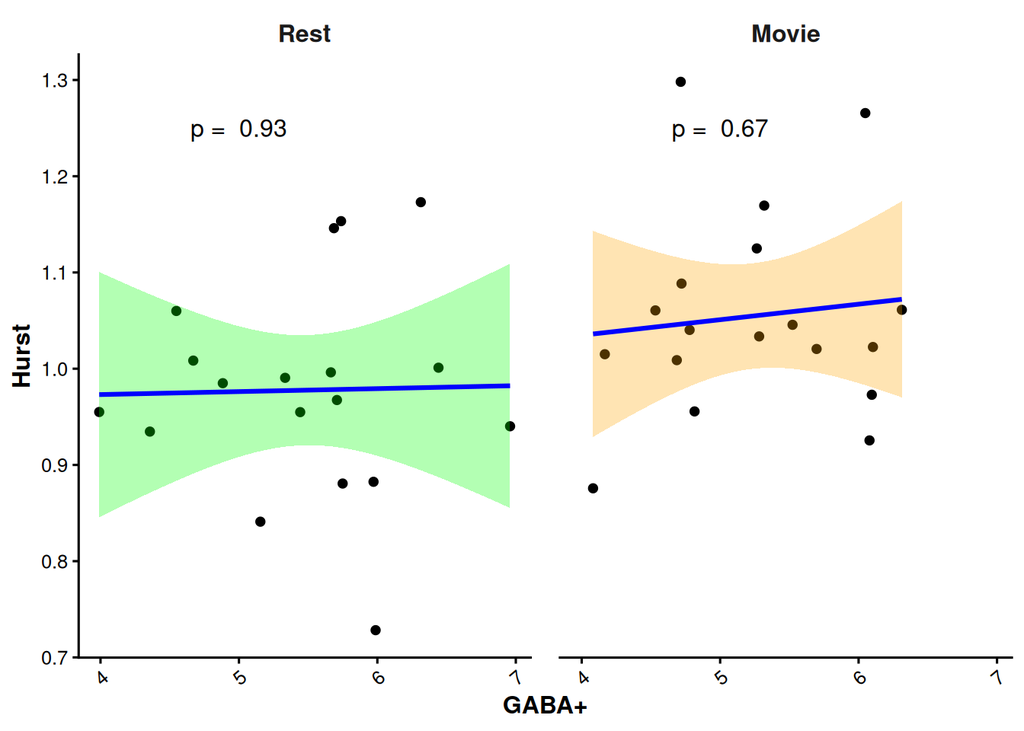

```r
dat_text <- data.frame(
  label = c(paste("p = ", round(gabaplush_rest_pearson$p.value, 2)), paste("p = ", round(gabaplush_movie_pearson$p.value, 2))),
  Condition = c("Rest", "Movie"),
  x = c(5, 5),
  y = c(1.25, 1.25)
)
(gabaplus_hurst_plot <- ggplot(data = gabaplush_df, aes(x = GABAplus, y = Hurst, color = Condition, fill = Condition)) +
  geom_point(color = "black") +
  geom_smooth(method = "lm", color = "blue", aes(fill = Condition), alpha = 0.3) +
  theme_classic(base_size = 12) +
  theme(
    strip.background = element_blank(), strip.text.x = element_text(size = 12, face = "bold"),
    axis.title = element_text(face = "bold"), legend.title = element_text(face = "bold")
  ) +
  theme(legend.position = "none")+
  xlab("GABA+") +
  ylab("Hurst") +
  facet_wrap(~ factor(Condition, levels = c("Rest", "Movie"))) +
  geom_text(
    data = dat_text,
    mapping = aes(x = x, y = y, label = label),
    inherit.aes = FALSE
  )+
  scale_x_continuous(guide = guide_axis(angle = 40)) +
  theme(panel.spacing = unit(1, "lines")) +
  scale_fill_manual(values = c("Rest" = "green", "Movie" = "orange"))
)
```

```r
png(file = "GABAplus_Hurst_Plot.png", width = 7, height = 4, units = "in", res = 300)
gabaplus_hurst_plot
dev.off()
```

Is EI correlated with Hurst?

```
In [102]:
```

```r
ei <- as.data.frame(glx / gabaplus$GABAplus)
ei$Condition <- gabaplus$Condition
names(ei)[1] <- "EI"
eih_df <- data.frame(hurst, ei)
names(eih_df)[1] <- "Hurst"
pearson_hurst_ei <- cor.test(eih_df$EI, eih_df$Hurst, method = "pearson")

eih_rest <- dplyr::filter(eih_df, Condition == "Rest")
eih_rest_pearson <- cor.test(eih_rest$Hurst, eih_rest$EI, method = "pearson")
print(eih_rest_pearson)
```

```
    Pearson's product-moment correlation

data:  eih_rest$Hurst and eih_rest$EI
t = -0.14069, df = 16, p-value = 0.8899
alternative hypothesis: true correlation is not equal to 0
95 percent confidence interval:
 -0.4939148  0.4389229
sample estimates:
        cor
-0.03515012
```

```r
eih_movie <- dplyr::filter(eih_df, Condition == "Movie")
eih_movie_pearson <- cor.test(eih_movie$Hurst, eih_movie$EI, method = "pearson")
print(eih_movie_pearson)
```

```
    Pearson's product-moment correlation

data:  eih_movie$Hurst and eih_movie$EI
t = -1.3412, df = 16, p-value = 0.1986
alternative hypothesis: true correlation is not equal to 0
95 percent confidence interval:
 -0.6833460  0.1749385
sample estimates:
       cor
-0.3178952
```

```
In [103]:
```

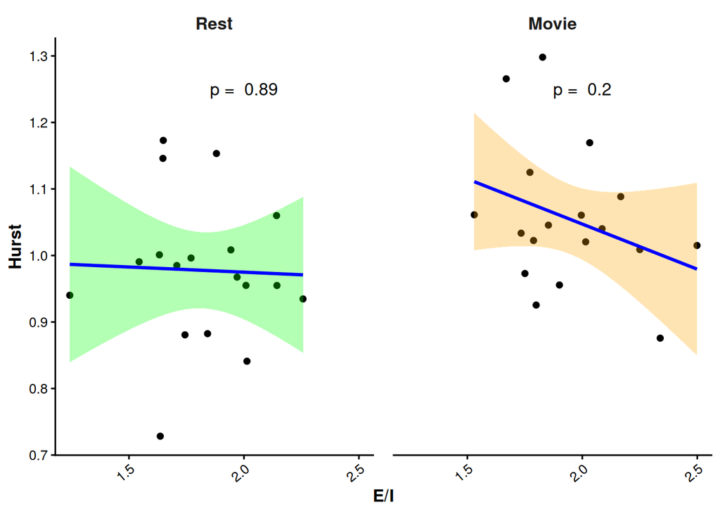

```r
dat_text <- data.frame(
  label = c(paste("p = ", round(eih_rest_pearson$p.value, 2)), paste("p = ", round(eih_movie_pearson$p.value, 2))),
  Condition = c("Rest", "Movie"),
  x = c(2, 2),
  y = c(1.25, 1.25)
)
(ei_hurst_plot <- ggplot(data = eih_df, aes(x = EI, y = Hurst, color = Condition, fill = Condition)) +
  geom_point(color = "black") +
  geom_smooth(method = "lm", color = "blue", aes(fill = Condition), alpha = 0.3) +
  theme_classic(base_size = 12) +
  theme(
    strip.background = element_blank(), strip.text.x = element_text(size = 12, face = "bold"),
    axis.title = element_text(face = "bold"), legend.title = element_text(face = "bold")
  ) +
  theme(legend.position = "none") +
  xlab("E/I") +
  ylab("Hurst") +
  facet_wrap(~ factor(Condition, levels = c("Rest", "Movie"))) +
  geom_text(
    data = dat_text,
    mapping = aes(x = x, y = y, label = label),
    inherit.aes = FALSE
  ) +
  scale_x_continuous(guide = guide_axis(angle = 40)) +
  theme(panel.spacing = unit(1, "lines"))+
  scale_fill_manual(values = c("Rest" = "green", "Movie" = "orange"))
)
```

```r
png(file = "EI_Hurst_Plot.png", width = 7, height = 4, units = "in", res = 300)
ei_hurst_plot
dev.off()
```

```
In [104]:
```

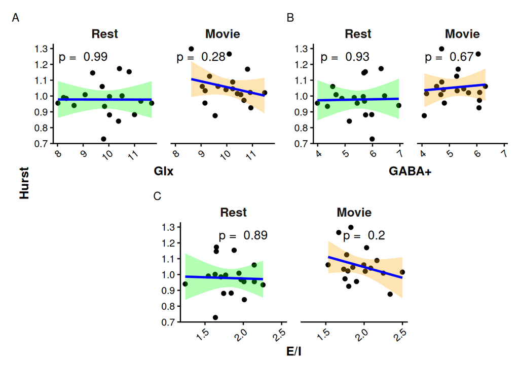

```r
layout <- "
AABB
#CC#
"
glx_hurst_plot + gabaplus_hurst_plot + ei_hurst_plot + plot_layout(design=layout, guides = 'collect', axes = 'collect', axis_titles = 'collect') + plot_annotation(tag_levels = 'A') & theme(plot.tag = element_text(size = 11))
```

# Gannet Analysis

```
In [105]:
```

```r
df <- df %>% rename(Rest_GABAGannet = Rest_mega_gannet_gabaplus, Movie_GABAGannet = Movie_mega_gannet_gabaplus, Rest_GlxGannet = Rest_mega_gannet_glx, Movie_GlxGannet = Movie_mega_gannet_glx)
```

# Linear Mixed Effects (Welch Full Freq)

```
In [106]:
```

```r
gannetdf_lme <- df %>%
  select(Subject, Rest_Hurst, Movie_Hurst,  Rest_GlxGannet, Movie_GlxGannet, Rest_GABAGannet, Movie_GABAGannet, Rest_mega_osprey_waterfwhm, Movie_mega_osprey_waterfwhm, Rest_mega_osprey_freqshift, Movie_mega_osprey_freqshift, Rest_MeanFD, Movie_MeanFD) %>%
  rename(Rest_FWHMMEGA = Rest_mega_osprey_waterfwhm, Movie_FWHMMEGA = Movie_mega_osprey_waterfwhm, Rest_FreqShiftMEGA = Rest_mega_osprey_freqshift, Movie_FreqShiftMEGA = Movie_mega_osprey_freqshift)
subjects_lme <- subjects %>% select(Age, Subject, Sex)
gannetdf_lme <- full_join(gannetdf_lme, subjects_lme, by = "Subject")
gannetdf_lme$Sex <- as.factor(gannetdf_lme$Sex)
```

```
In [107]:
```

```r
gannetdf_lme <- gannetdf_lme %>% pivot_longer(
  cols = -c(Age, Sex, Subject), # Exclude the Subject column from the transformation
  names_to = c("Condition", ".value"), # Split original column names
  names_pattern = "(.*)_(.*)" # Pattern to split the original column names
)
gannetdf_lme$EI <- gannetdf_lme$GlxGannet / gannetdf_lme$GABAGannet
gannetdf_lme$Condition <- as.factor(gannetdf_lme$Condition)
```

```
In [108]:
```

```r
gannetmodel <- lme4::lmer(Hurst ~ EI + Condition + FWHMMEGA + FreqShiftMEGA + MeanFD + (1 | Subject), data = gannetdf_lme)
summary(gannetmodel)
```

```
Linear mixed model fit by REML ['lmerMod']
Formula: Hurst ~ EI + Condition + FWHMMEGA + FreqShiftMEGA + MeanFD +
    (1 | Subject)
   Data: gannetdf_lme

REML criterion at convergence: -48.8

Scaled residuals:
    Min      1Q  Median      3Q     Max
-1.5825 -0.5544  0.0292  0.5185  1.9883

Random effects:
 Groups   Name        Variance Std.Dev.
 Subject  (Intercept) 0.005474 0.07399
 Residual             0.004821 0.06944
Number of obs: 36, groups:  Subject, 18

Fixed effects:
              Estimate Std. Error t value
(Intercept)    1.19822    0.25842   4.637
EI            -0.07190    0.06892  -1.043
ConditionRest -0.07921    0.02389  -3.315
FWHMMEGA       0.02505    0.02622   0.955
FreqShiftMEGA  0.01138    0.01796   0.634
MeanFD        -0.76331    0.80587  -0.947

Correlation of Fixed Effects:
            (Intr) EI     CndtnR FWHMME FSMEGA
EI          -0.470
ConditinRst -0.116  0.001
FWHMMEGA    -0.632 -0.304  0.048
FrqShftMEGA  0.296  0.140  0.138 -0.308
MeanFD      -0.059 -0.191  0.217 -0.027  0.326
```

```
In [109]:
```

```r
gannetmodel <- lmerTest::lmer(Hurst ~ EI + Condition +  FWHMMEGA +  FreqShiftMEGA + MeanFD + (1 | Subject), data = gannetdf_lme)
(gannetmodel_summary <- summary(gannetmodel))
```

```
Linear mixed model fit by REML. t-tests use Satterthwaite's method [
lmerModLmerTest]
Formula: Hurst ~ EI + Condition + FWHMMEGA + FreqShiftMEGA + MeanFD +
    (1 | Subject)
   Data: gannetdf_lme

REML criterion at convergence: -48.8

Scaled residuals:
    Min      1Q  Median      3Q     Max
-1.5825 -0.5544  0.0292  0.5185  1.9883

Random effects:
 Groups   Name        Variance Std.Dev.
 Subject  (Intercept) 0.005474 0.07399
 Residual             0.004821 0.06944
Number of obs: 36, groups:  Subject, 18

Fixed effects:
              Estimate Std. Error       df t value Pr(>|t|)
(Intercept)    1.19822    0.25842 22.39221   4.637 0.000122 ***
EI            -0.07190    0.06892 29.95627  -1.043 0.305188
ConditionRest -0.07921    0.02389 14.91040  -3.315 0.004741 **
FWHMMEGA       0.02505    0.02622 27.38004   0.955 0.347732
FreqShiftMEGA  0.01138    0.01796 24.92891   0.634 0.531992
MeanFD        -0.76331    0.80587 29.75671  -0.947 0.351176
---
Signif. codes:  0 '***' 0.001 '**' 0.01 '*' 0.05 '.' 0.1 ' ' 1

Correlation of Fixed Effects:
            (Intr) EI     CndtnR FWHMME FSMEGA
EI          -0.470
ConditinRst -0.116  0.001
FWHMMEGA    -0.632 -0.304  0.048
FrqShftMEGA  0.296  0.140  0.138 -0.308
MeanFD      -0.059 -0.191  0.217 -0.027  0.326
```

```
In [110]:
```

```r
(gannetr2_values <- performance::r2(gannetmodel))
```

```
# R2 for Mixed Models

  Conditional R2: 0.640
     Marginal R2: 0.232
```

```
In [111]:
```

```r
(gannetconfint_values <- lme4::confint.merMod(gannetmodel, method="Wald"))
```

```
                    2.5 %      97.5 %
.sig01                 NA          NA
.sigma                 NA          NA
(Intercept)    0.69172189  1.70471289
EI            -0.20697858  0.06318077
ConditionRest -0.12603224 -0.03238172
FWHMMEGA      -0.02634328  0.07645198
FreqShiftMEGA -0.02381729  0.04658214
MeanFD        -2.34278442  0.81617329
```

```
In [112]:
```

```r
report(gannetmodel)
```

```
We fitted a linear mixed model (estimated using REML and nloptwrap optimizer)
to predict Hurst with EI, Condition, FWHMMEGA, FreqShiftMEGA and MeanFD
(formula: Hurst ~ EI + Condition + FWHMMEGA + FreqShiftMEGA + MeanFD). The
model included Subject as random effect (formula: ~1 | Subject). The model's
total explanatory power is substantial (conditional R2 = 0.64) and the part
related to the fixed effects alone (marginal R2) is of 0.23. The model's
intercept, corresponding to EI = 0, Condition = Movie, FWHMMEGA = 0,
FreqShiftMEGA = 0 and MeanFD = 0, is at 1.20 (95% CI [0.67, 1.73], t(28) =
4.64, p < .001). Within this model:

  - The effect of EI is statistically non-significant and negative (beta = -0.07,
95% CI [-0.21, 0.07], t(28) = -1.04, p = 0.306; Std. beta = -0.18, 95% CI
[-0.53, 0.17])
  - The effect of Condition [Rest] is statistically significant and negative
(beta = -0.08, 95% CI [-0.13, -0.03], t(28) = -3.32, p = 0.003; Std. beta =
-0.69, 95% CI [-1.12, -0.26])
  - The effect of FWHMMEGA is statistically non-significant and positive (beta =
0.03, 95% CI [-0.03, 0.08], t(28) = 0.96, p = 0.348; Std. beta = 0.18, 95% CI
[-0.20, 0.55])
  - The effect of FreqShiftMEGA is statistically non-significant and positive
(beta = 0.01, 95% CI [-0.03, 0.05], t(28) = 0.63, p = 0.531; Std. beta = 0.10,
95% CI [-0.22, 0.41])
  - The effect of MeanFD is statistically non-significant and negative (beta =
-0.76, 95% CI [-2.41, 0.89], t(28) = -0.95, p = 0.352; Std. beta = -0.17, 95%
CI [-0.53, 0.19])

Standardized parameters were obtained by fitting the model on a standardized
version of the dataset. 95% Confidence Intervals (CIs) and p-values were
computed using a Wald t-distribution approximation.
```

```
In [113]:
```

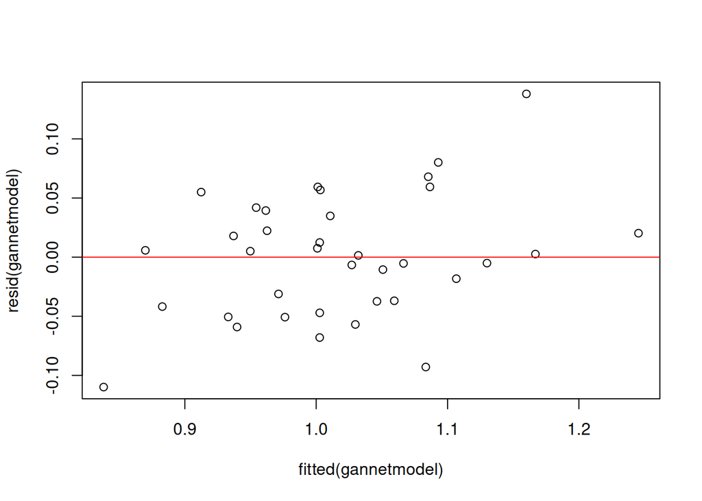

```r
# Plotting residuals to check assumptions
plot(resid(gannetmodel) ~ fitted(gannetmodel))
abline(h = 0, col = "red")
```

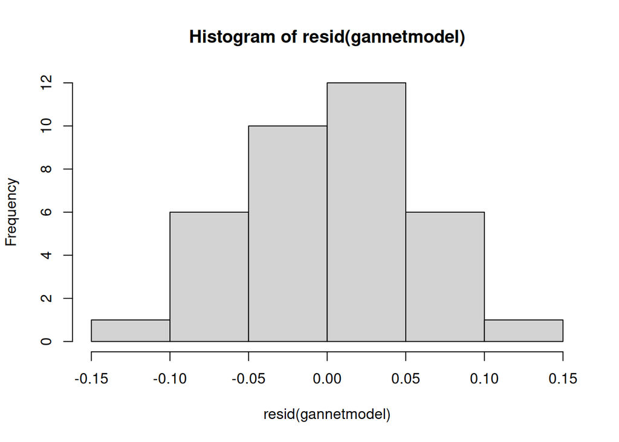

```r
hist(resid(gannetmodel)) # Check for normality
```

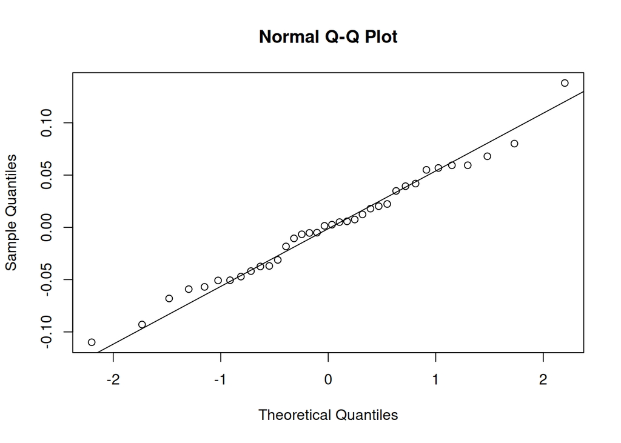

```r
# QQ plot for normality of residuals
qqnorm(resid(gannetmodel))
qqline(resid(gannetmodel))
```

## Glx

How does glutamate change with condition?

```
In [114]:
```

```r
gannetglx_df <- dplyr::select(df, Subject, Rest_GlxGannet, Movie_GlxGannet)
gannetglx_effect_size <- cohensD(gannetglx_df$Rest_GlxGannet, gannetglx_df$Movie_GlxGannet)
(ttest_gannetglx <- t.test(gannetglx_df$Rest_GlxGannet, gannetglx_df$Movie_GlxGannet, paired = TRUE))
```

```
    Paired t-test

data:  gannetglx_df$Rest_GlxGannet and gannetglx_df$Movie_GlxGannet
t = 0.8114, df = 17, p-value = 0.4283
alternative hypothesis: true mean difference is not equal to 0
95 percent confidence interval:
 -0.1946919  0.4380252
sample estimates:
mean difference
      0.1216667
```

```r
gannetglx_df <- reshape2::melt(gannetglx_df, id.vars = c("Subject"))
gannetglx_df$variable <- gsub("_.*", "", gannetglx_df$variable)
names(gannetglx_df) <- c("Sub", "Condition", "gannetglx")
gannetglx_df$Condition <- factor(gannetglx_df$Condition, levels = c("Rest", "Movie"))

gannetglx_df$Sex <- sub_dem$Sex
gannetglx_m <- gannetglx_df %>% dplyr::filter(Sex == "M")
gannetglx_f <- gannetglx_df %>% dplyr::filter(Sex == "F")
t.test(gannetglx_m$gannetglx, gannetglx_f$gannetglx)
```

```
    Welch Two Sample t-test

data:  gannetglx_m$gannetglx and gannetglx_f$gannetglx
t = -3.8845, df = 27.722, p-value = 0.0005797
alternative hypothesis: true difference in means is not equal to 0
95 percent confidence interval:
 -1.4002001 -0.4330499
sample estimates:
mean of x mean of y
 10.26938  11.18600
```

```r
gannetglx_df$Age <- sub_dem$Age
cor.test(gannetglx_df$gannetglx, gannetglx_df$Age)
```

```
    Pearson's product-moment correlation

data:  gannetglx_df$gannetglx and gannetglx_df$Age
t = -0.6845, df = 34, p-value = 0.4983
alternative hypothesis: true correlation is not equal to 0
95 percent confidence interval:
 -0.4287054  0.2203865
sample estimates:
       cor
-0.1165909
```

```
In [115]:
```

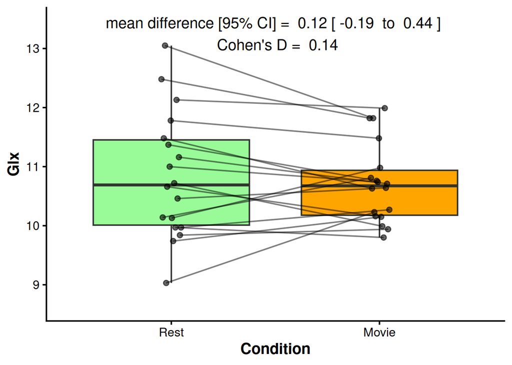

```r
minmax <- c(min(gannetglx_df$gannetglx), max(gannetglx_df$gannetglx))
space <- (minmax[2] - minmax[1]) / 10
(gannetglx_boxplot <- ggplot(gannetglx_df, aes(x = Condition, y = gannetglx, fill = Condition)) +
  scale_fill_manual(values = c("#98FB98", "#FFA500"), guide = "none") +
  theme_classic(base_size = 15) +
  theme(axis.title = element_text(face = "bold"), legend.position = "none") +
  geom_boxplot(outlier.shape = NA) +
  geom_point(alpha = 0.6, position = position_jitterdodge(dodge.width = 0.1, jitter.width = 0.01, seed = 123), aes(group = Sub)) +
  geom_line(aes(group = Sub), position = position_jitterdodge(dodge.width = 0.1, jitter.width = 0.01, seed = 123), alpha = 0.5) +
  ylab("Glx") +
  ylim(minmax[1] - space, minmax[2] + space) +
  annotate(geom = "text", x = 1.5, y = minmax[2] + space / 2, label = paste(
    "mean difference [95% CI] = ",
    round(as.numeric(ttest_gannetglx$estimate), 2),
    "[",
    round(as.numeric(ttest_gannetglx$conf.int)[1], 2),
    " to ",
    round(as.numeric(ttest_gannetglx$conf.int)[2], 2),
    "]",
    "\n Cohen's D = ",
    round(gannetglx_effect_size, 2)
  ))
)
```

```r
png(file = "gannetglxtamate_v_Condition_Plot_Gannet.png", width = 7, height = 4, units = "in", res = 300)
gannetglx_boxplot
dev.off()
```

```r
t.test(df$Rest_GlxGannet, df$Movie_GlxGannet, paired = T)
```

```
    Paired t-test

data:  df$Rest_GlxGannet and df$Movie_GlxGannet
t = 0.8114, df = 17, p-value = 0.4283
alternative hypothesis: true mean difference is not equal to 0
95 percent confidence interval:
 -0.1946919  0.4380252
sample estimates:
mean difference
      0.1216667
```

```
In [116]:
```

```r
(gannetglx_stats <- gannetglx_df %>% group_by(Condition) %>% summarise(mean = round(mean(gannetglx), 2), sd = round(sd(gannetglx), 2)))
```

```
# A tibble: 2 × 3
  Condition  mean    sd
  <fct>     <dbl> <dbl>
1 Rest       10.8  1.06
2 Movie      10.7  0.68
```

## GABA+

How does GABA change with condition?

```
In [117]:
```

```r
gannetgaba_df <- dplyr::select(df, Subject, Rest_GABAGannet, Movie_GABAGannet)
gannetgaba_effect_size <- cohensD(gannetgaba_df$Rest_GABAGannet, gannetgaba_df$Movie_GABAGannet)
(ttest_gannetgaba <- t.test(gannetgaba_df$Rest_GABAGannet, gannetgaba_df$Movie_GABAGannet, paired = TRUE))
```

```
    Paired t-test

data:  gannetgaba_df$Rest_GABAGannet and gannetgaba_df$Movie_GABAGannet
t = 0.99406, df = 17, p-value = 0.3341
alternative hypothesis: true mean difference is not equal to 0
95 percent confidence interval:
 -0.06734511  0.18734511
sample estimates:
mean difference
           0.06
```

```r
gannetgaba_df <- reshape2::melt(gannetgaba_df, id.vars = c("Subject"))
gannetgaba_df$variable <- gsub("_.*", "", gannetgaba_df$variable)
names(gannetgaba_df) <- c("Sub", "Condition", "GABAplus")
gannetgaba_df$Condition <- factor(gannetgaba_df$Condition, levels = c("Rest", "Movie"))

gannetgaba_df$Sub <- gannetgaba_df$Sub
gannetgaba_df$Sex <- sub_dem$Sex
gannetgaba_m <- gannetgaba_df %>% dplyr::filter(Sex == "M")
gannetgaba_f <- gannetgaba_df %>% dplyr::filter(Sex == "F")
t.test(gannetgaba_m$GABAplus, gannetgaba_f$GABAplus)
```

```
    Welch Two Sample t-test

data:  gannetgaba_m$GABAplus and gannetgaba_f$GABAplus
t = -0.95634, df = 31.138, p-value = 0.3463
alternative hypothesis: true difference in means is not equal to 0
95 percent confidence interval:
 -0.3727362  0.1347362
sample estimates:
mean of x mean of y
    3.495     3.614
```

```r
gannetgaba_df$Age <- sub_dem$Age
cor.test(gannetgaba_df$GABAplus, gannetgaba_df$Age)
```

```
    Pearson's product-moment correlation

data:  gannetgaba_df$GABAplus and gannetgaba_df$Age
t = 0.77421, df = 34, p-value = 0.4442
alternative hypothesis: true correlation is not equal to 0
95 percent confidence interval:
 -0.205815  0.441083
sample estimates:
      cor
0.1316206
```

```
In [118]:
```

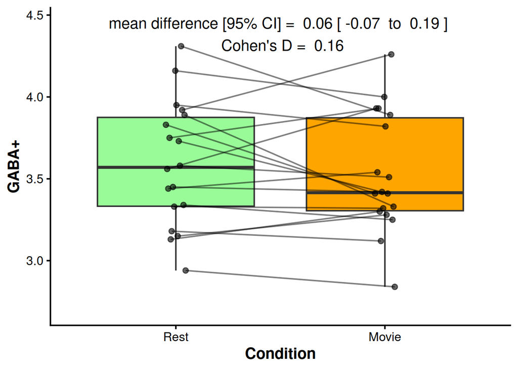

```r
minmax <- c(min(gannetgaba_df$GABAplus), max(gannetgaba_df$GABAplus))
space <- (minmax[2] - minmax[1]) / 10
(gannetgaba_boxplot <- ggplot(gannetgaba_df, aes(x = Condition, y = GABAplus, fill = Condition)) +
  scale_fill_manual(values = c("#98FB98", "#FFA500"), guide = "none") +
  theme_classic(base_size = 15) +
  ylab("GABA+") +
  theme(axis.title = element_text(face = "bold"), legend.position = "none") +
  geom_boxplot(outlier.shape = NA) +
  geom_point(alpha = 0.6, position = position_jitterdodge(dodge.width = 0.1, jitter.width = 0.01, seed = 123), aes(group = Sub)) +
  geom_line(aes(group = Sub), position = position_jitterdodge(dodge.width = 0.1, jitter.width = 0.01, seed = 123), alpha = 0.5) +
  ylim(minmax[1] - space, minmax[2] + space) +
  annotate(geom = "text", x = 1.5, y = minmax[2] + space / 2, label = paste(
    "mean difference [95% CI] = ",
    round(as.numeric(ttest_gannetgaba$estimate), 2),
    "[",
    round(as.numeric(ttest_gannetgaba$conf.int)[1], 2),
    " to ",
    round(as.numeric(ttest_gannetgaba$conf.int)[2], 2),
    "]",
    "\n Cohen's D = ",
    round(gannetgaba_effect_size, 2)
  ))
)
```

```r
png(file = "GABA_v_Condition_Plot_Gannet.png", width = 7, height = 4, units = "in", res = 300)
gannetgaba_boxplot
dev.off()
```

```
In [119]:
```

```r
(gannetgaba_stats <- gannetgaba_df %>% group_by(Condition) %>% summarise(mean = round(mean(GABAplus), 2), sd = round(sd(GABAplus), 2)))
```

```
# A tibble: 2 × 3
  Condition  mean    sd
  <fct>     <dbl> <dbl>
1 Rest       3.59  0.38
2 Movie      3.53  0.36
```